# IATI as network data: results

Traceability of funding in IATI data, from the IATI Bulk Data Service copy of 30 October 2026

Published

November 18, 2026

*This page shows the results of the pipeline on the IATI Bulk Data Service copy whose index was created on 2026-10-30 (pipeline code version ec148f5). It reads only the pipeline’s output folder. The figures are those of the working paper on network and traceability, with the paper’s captions and numbers: “Section”, “Table” and “Annex” in a caption refer to the paper. Interactive tabs let you explore the same data. Definitions are in `docs/methods_decisions.md` and `docs/indicators.md`, and every output column in `docs/data_dictionary.md`.*

## Summary

**Note**

For the key headline results, readers and users should see the final report. The points below are a selection of results, made before the final report was prepared.

This report describes the full run of the traceability pipeline on the IATI Bulk Data Service copy whose index was created on 2026-10-30. It covers what each stage did to the data, the links between activities and between organizations, the chains of funding, and the indicators.

- **Activities connected.** Of 794,616 activities with transactions, 14,353 (1.8%) are connected to an activity of another organization by a plausible link (indicator 1).
- **Chain depth.** Funding can be followed activity by activity for a mean of 1.09 steps from each origin (indicator 6). The longest chain has 5 steps.
- **Organization paths.** Counted by distinct sequences of organizations, 49.6% of traceable routes have two or more steps (indicator 6e).
- **Receiver IDs.** 19.8% of outgoing commitments and disbursements give a valid receiver organization ID (indicator 3), against 62.8% of incoming transactions giving a valid provider ID (indicator 2).
- **The gap.** Organization IDs link 22,523 organizations into an almost fully connected network (not counting 11,240 codes that UNICEF gives its own partners). Followed activity by activity, the same funding falls apart into 2,602 separate pieces covering 14,716 activities.

## 1. Terms

The counts in this report are in different units. They are not interchangeable.

| Term | What it is | In the XML |
| --- | --- | --- |
| **Activity** | A project or programme as published, with its own `iati-identifier`. It holds many transactions. | `<iati-activity>` |
| **Transaction** | One financial flow in an activity: commitment, disbursement, expenditure, incoming funds. | `<transaction>` |
| **Link** | A pair of activities (funder → receiver), connected because a transaction in one names the other’s activity ID. One link usually rests on several transactions. | `provider-activity-id`, `receiver-activity-id` |
| **Organization link** | A pair of organizations, connected because a transaction names the other’s organization ID. | `provider-org ref`, `receiver-org ref` |
| **Chain** | A sequence of links from an origin activity (no traced funder) to an end activity (no traced recipient). Length is in steps. | — |
| **Organization path** | The sequence of organizations along a chain. Many chains can share one. | — |

How the units nest

| Level | Activities | Links | Transactions |
| --- | --- | --- | --- |
| All data after cleaning | 894,287 | - | 11,446,196 |
| Transactions naming a published counterpart activity | - | 42,043 | 145,464 |
| Network: plausible links between different organisations | 14,716 | 13,024 | 68,460 |
| Used in chains | 14,698 | 12,992 | 68,074 |

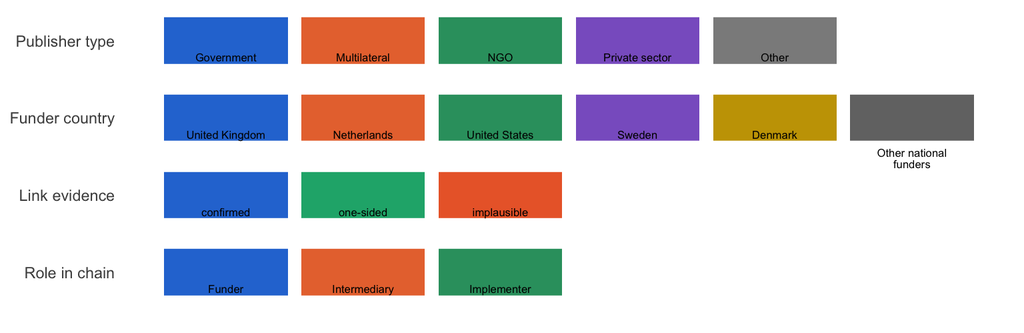

*The colors used in every figure: one set each for publisher type, funder country, link evidence and role in a chain.*

## 2. The process

Row counts after each step

| Stage | Step | Activities | Transactions |
| --- | --- | --- | --- |
| 1 Parse | Read from all XML files | 900,146 | 11,496,865 |
| 1 Parse | Unreadable files excluded | 899,860 | 11,495,053 |
| 2 Clean | Activities without identifier removed | 899,840 |  |
| 2 Clean | One copy per activity | 894,287 | 11,446,196 |
| 2 Clean | Exact duplicate transactions flagged (left out of links and indicators) |  | 11,220,990 |

Files in the bulk copy

| Item | Count |
| --- | --- |
| Datasets in the index | 13,989 |
| Datasets missing from the copy | 747 |
| XML files read | 13,242 |
| Organisation files (no transactions, skipped) | 1,721 |
| Files that could not be read | 10 |

The stages and their settings are described in `README.md`. The pipeline ran in 12 minutes. Package versions and every setting used are recorded in `run_manifest.json`.

## 3. Links and their evidence

Links between different organisations, by plausibility and evidence

| plausibility | implausible | one-sided | confirmed | Total |
| --- | --- | --- | --- | --- |
| org matches | 0 | 9579 | 733 | 10312 |
| no org ref | 0 | 2332 | 0 | 2332 |
| unrecognised org ref | 0 | 378 | 2 | 380 |
| names another publisher | 140 | 0 | 0 | 140 |
| reverses own funding link | 40 | 0 | 0 | 40 |

Of 42,043 links, 28,839 (69%) join two activities of the same organization; these are not used in the network. Of the 13,204 links between organizations, 735 (5.6%) are reported by both sides.

The plausibility rule is set out in `docs/methods_decisions.md`, section 3.1. Under it, 180 links are implausible, against 560 under the strict rule.

## 4. Chain depth in three units

The same chains can be counted three ways, and they give different pictures:

- **Per chain:** each path counts once.
- **Per origin:** each starting activity counts once, by its longest chain. This is the pilot’s indicator 6.
- **Per organization path:** each distinct sequence of organizations counts once.

**Figure**

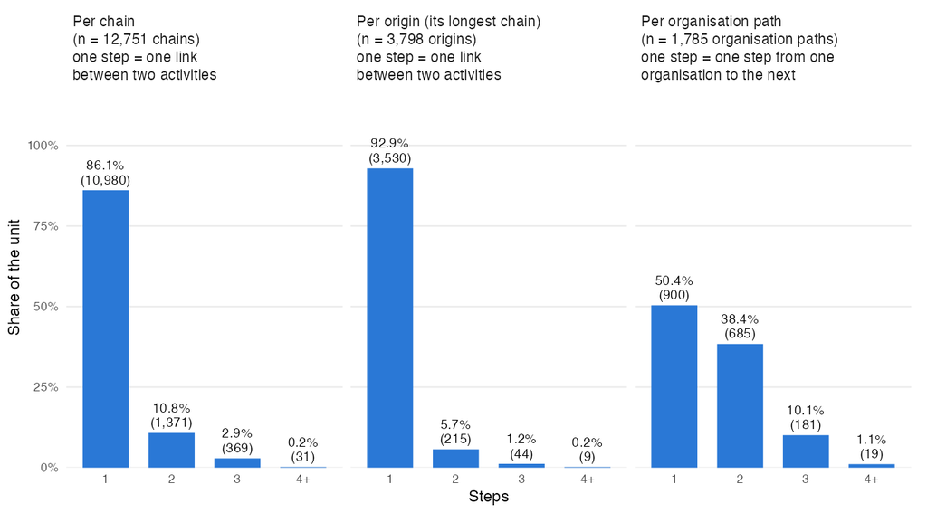

**Figure 10.** Figure 10. Chain depth in three units (Table 12): the chain-level indicators of Table 4 (Section 6.2). Left: chains by number of steps (indicators 6c, longest chain, 5 steps, and 6d, chains with 2 or more steps, 13.9%). Centre: origins by the steps of their longest chain (indicators 6, mean 1.09 steps, and 6b, 7.1% with 2 or more steps). Right: distinct organization paths by number of steps (indicator 6e, 49.6% with 2 or more steps). Labels: share of the unit, with the count in brackets. Global network, all years. Units: chains; origins; organization paths.

**By year**

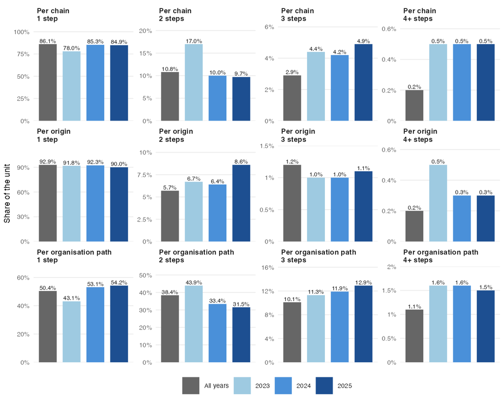

**Figure 10b.** Figure 10b. Chain depth in three units, by year: the indicators of Figure 10 (Table 4, chain level, Section 6.2) for the chains that pass through at least one activity with a transaction dated in the year, and the origins and organization paths of those chains. Each small panel is one unit and number of steps (rows: per chain, per origin by its longest chain, per organization path); bars: all years and 2023, 2024, 2025. The vertical scale differs between panels. n: 2023: 5,535 chains, 1,120 organization paths, 1,628 origins; 2024: 4,816 chains, 868 organization paths, 1,521 origins; 2025: 4,065 chains, 801 organization paths, 1,083 origins. Units: chains; origins; organization paths.

**Interactive**

[interactive chart not shown]

**Table**

Table view of the figure above

| steps | n_Per chain | percent_Per chain | n_Per origin (longest chain) | percent_Per origin (longest chain) | n_Per organisation path | percent_Per organisation path |
| --- | --- | --- | --- | --- | --- | --- |
| 1 | 10980 | 86.1 | 3530 | 92.9 | 900 | 50.4 |
| 2 | 1371 | 10.8 | 215 | 5.7 | 685 | 38.4 |
| 3 | 369 | 2.9 | 44 | 1.2 | 181 | 10.1 |
| 4+ | 31 | 0.2 | 9 | 0.2 | 19 | 1.1 |

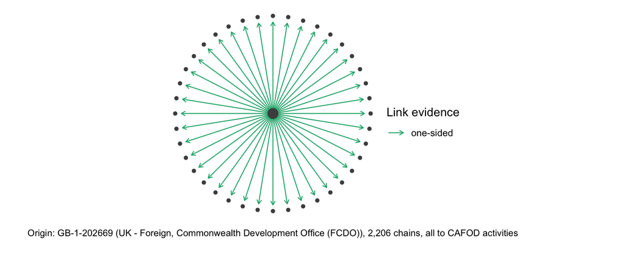

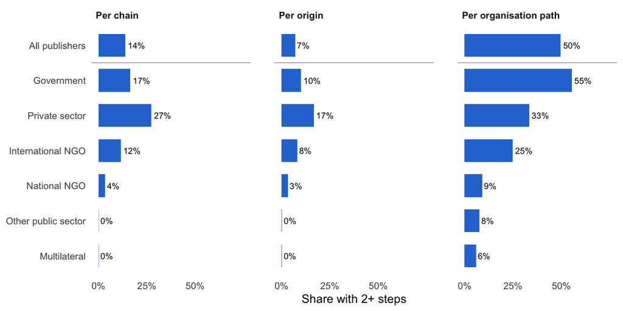

### Explore organization paths and chains

Every organization path (`org_paths.csv`), and every chain of two or more steps (`chains.csv`), with search and column filters. For example, type an organization name into the search box to see every traceable route through it.

**Organization paths**

| path | steps | chains | best evidence | countries | years | origin group |
| --- | --- | --- | --- | --- | --- | --- |
| UK - Foreign, Commonwealth Development Office (FCDO) &gt; Girls' Education Challenge - Fund Manager PwC &gt; IRC-UK &gt; International Rescue Committee Inc. &gt; Concern Worldwide UK &gt; Concern Worl… | 5 | 2 | one-sided | ET;GH;KE;MW;NP;PK;SL;ZW | 2018-2023 | Government |
| Ministry of Foreign Affairs of the Netherlands &gt; SNV Netherlands Development Organisation &gt; Join For Water (Protos) &gt; SNV Netherlands Development Organisation &gt; Oxfam Novib &gt; Oxfam-Queb… | 5 | 1 | one-sided | BJ | 2016-2023 | Government |
| UK - Foreign, Commonwealth Development Office (FCDO) &gt; IRC-UK &gt; International Rescue Committee Inc. &gt; Concern Worldwide UK &gt; Concern Worldwide | 4 | 4 | one-sided | SL | 2018-2025 | Government |
| UK - Foreign, Commonwealth Development Office (FCDO) &gt; Girls' Education Challenge - Fund Manager PwC &gt; IRC-UK &gt; International Rescue Committee Inc. &gt; Restless Development | 4 | 4 | one-sided | ET;GH;KE;MW;NP;PK;SL;ZW | 2018-2025 | Government |
| UK - Foreign, Commonwealth Development Office (FCDO) &gt; Girls' Education Challenge - Fund Manager PwC &gt; IRC-UK &gt; International Rescue Committee Inc. &gt; Concern Worldwide | 4 | 2 | one-sided | ET;GH;KE;MW;NP;PK;SL;ZW | 2018-2025 | Government |
| UK - Foreign, Commonwealth Development Office (FCDO) &gt; Girls' Education Challenge - Fund Manager PwC &gt; Voluntary Service Overseas (VSO) &gt; Humanity &amp; Inclusion - Handicap International UK … | 4 | 2 | one-sided | CD;ET;GH;KE;MW;MZ;NG;NP;PK;RW;SL;TZ;UG;ZM;ZW | 2017-2023 | Government |
| UK - Foreign, Commonwealth Development Office (FCDO) &gt; MannionDanniels &gt; Orbis Charitable Trust &gt; Orbis International &gt; Nepal Netra Jyoti Sangh | 4 | 2 | one-sided | AF;AO;BD;BI;CD;CF;CM;ET;GH;HT;ID;KE;KH;LA;LB;LR;ML;MW;MZ;NG;NP;PK;RW;SD;SL;SN;SS;SY;TG;TZ;UG;YE;ZM;ZW | 2018-2023 | Government |
| UK - Foreign, Commonwealth Development Office (FCDO) &gt; MannionDanniels &gt; Orbis Charitable Trust &gt; Orbis International &gt; Orbis Africa | 4 | 2 | one-sided | AF;AO;BD;BI;CD;CF;CM;ET;GH;HT;ID;KE;KH;LA;LB;LR;ML;MW;MZ;NG;NP;PK;RW;SD;SL;SN;SS;SY;TG;TZ;UG;YE;ZM;ZW | 2018-2023 | Government |
| Ministry of Foreign Affairs of the Netherlands &gt; Cordaid &gt; Oxfam Novib &gt; Oxfam GB &gt; Oxfam Novib | 4 | 2 | one-sided | CD;IQ | 2016-2021 | Government |
| UK - Foreign, Commonwealth Development Office (FCDO) &gt; Girls' Education Challenge - Fund Manager PwC &gt; Viva &gt; CRANE &gt; Mukisa Foundation | 4 | 1 | one-sided | CD;ET;GB;GH;KE;MZ;NG;NP;RW;SL;TZ;UG;ZM;ZW | 2017-2023 | Government |

[output cut: 1775 more lines]

**Chains of 2+ steps**

| path | activities | steps | weakest evidence | countries | years | why it stops |
| --- | --- | --- | --- | --- | --- | --- |
| VLIR-UOS - Vlaamse Interuniversitaire Raad - Flemish Interuniversity Council &gt; ARES - Académie de Recherche et d’Enseignement supérieur &gt; VLIR-UOS - Vlaamse Interuniversitaire Raad - Flemish Int… | BE-BCE_KBO-0418766123-PROG2017-2021_SO8 &gt; BE-BCE_KBO-0546740696-PG2017-2021 &gt; BE-BCE_KBO-0418766123-PROG2017-2021_SO3 | 2 | one-sided | BE;CD | 2017-2018 | receiver name only |
| African Disability Forum (ADF) &gt; ZOA &gt; African Disability Forum (ADF) | ET-MFA-150317-ADF-DRC2101 &gt; NL-KVK-41009723-NLD2101 &gt; ET-MFA-150317-ADF-HQ2101 | 2 | one-sided | BI;CD;ET;NL;SD;SS;UG | 2020-2025 | no receiver named |
| African Disability Forum (ADF) &gt; ZOA &gt; VNG International | ET-MFA-150317-ADF-DRC2101 &gt; NL-KVK-41009723-NLD2101 &gt; NL-KVK-27195046-11435.NLD | 2 | one-sided | BI;CD;ET;NL;SD;SS;UG | 2020-2025 | no receiver named |
| African Disability Forum (ADF) &gt; ZOA &gt; The Hague Academy for Local Governance | ET-MFA-150317-ADF-DRC2101 &gt; NL-KVK-41009723-NLD2101 &gt; NL-KVK-27293917-ZOA.WAA.21-25.NL | 2 | one-sided | BI;CD;ET;NL;SD;SS;UG | 2020-2025 | no receiver named |
| African Disability Forum (ADF) &gt; ZOA &gt; Stichting Leprazending Nederland - The Leprosy Mission Netherlands | ET-MFA-150317-ADF-DRC2101 &gt; NL-KVK-41009723-NLD2101 &gt; NL-KVK-41039028-NL2125-WAANL | 2 | one-sided | BI;CD;ET;NL;SD;SS;UG | 2020-2025 | no receiver named |
| African Disability Forum (ADF) &gt; ZOA &gt; SeeYou Foundation | ET-MFA-150317-ADF-DRC2101 &gt; NL-KVK-41009723-NLD2101 &gt; NL-KVK-41180500-489-1357 | 2 | one-sided | BI;CD;ET;NL;SD;SS;UG | 2020-2025 | receiver organisation ID only |
| UK - Foreign, Commonwealth Development Office (FCDO) &gt; Voluntary Service Overseas (VSO) &gt; Alfalit | GB-1-113747 &gt; GB-CHC-313757-MZ9 &gt; MZ-MOJ-203D-NP | 2 | one-sided | MZ | 2013-2017 | no receiver named |
| UK - Foreign, Commonwealth Development Office (FCDO) &gt; Voluntary Service Overseas (VSO) &gt; Anda | GB-1-113747 &gt; GB-CHC-313757-MZ9 &gt; MZ-MOJ-F30G1No89-MZ | 2 | one-sided | MZ | 2013-2017 | no receiver named |
| UK - Foreign, Commonwealth Development Office (FCDO) &gt; DAI Europe &gt; Nathan Associates London Ltd. | GB-1-114433 &gt; GB-COH-1858644-201980 &gt; GB-COH-02768268-654 | 2 | one-sided | PK;ZM | 2014-2020 | link only to own organisation or implausible |
| UK - Foreign, Commonwealth Development Office (FCDO) &gt; DAI Europe &gt; Nathan Associates London Ltd. | GB-1-114433 &gt; GB-COH-1858644-201980 &gt; GB-COH-02768268-GhanaMADE | 2 | one-sided | GH;PK;ZM | 2015-2020 | link only to own organisation or implausible |

[output cut: 1761 more lines]

## 5. Where chains stop

For each activity that receives funds but has no onward link in the network, the reason records the best evidence its outgoing transactions give about where the money went.

**Figure**

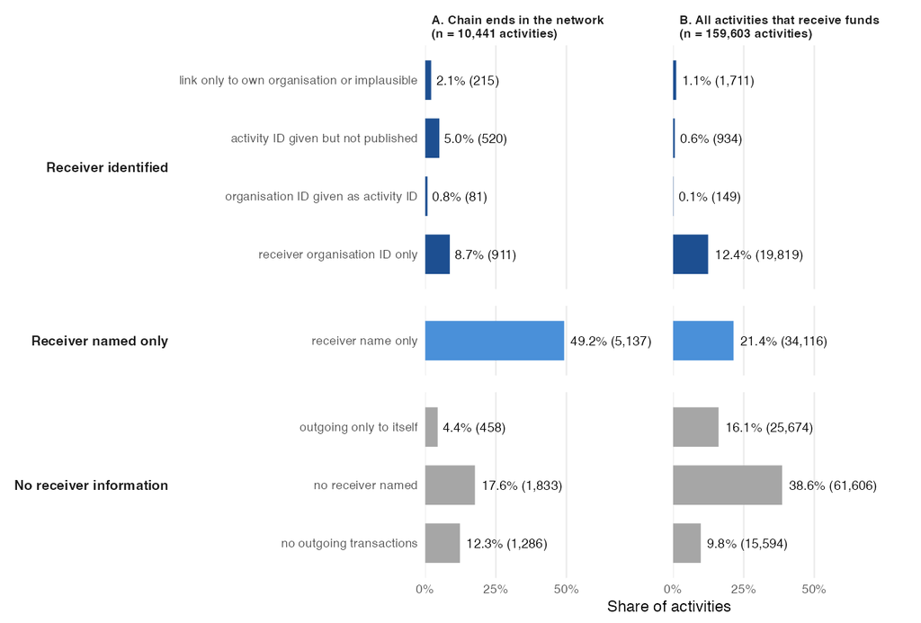

**Figure 13.** Figure 13. Why chains stop (Section 6.3). For each activity that receives funds but has no onward link in the network, the best evidence its outgoing commitments, disbursements and expenditure give about the next receiver; each activity is counted once, under the best evidence. The reasons follow the levels of Table 2 and are ordered from most to least information, in three groups: receiver identified (an organization identifier or an activity identifier is given; for the activity identifiers that do not resolve see indicators x1 and x1b of Table 4, Section 5.4), receiver named only (the ‘named’ level of Table 2), and no receiver information. A: activities where a chain in the network ends; B: all activities that receive funds, in the network or not. Labels: share, with the number of activities in brackets. All years. Unit: activities.

**By year**

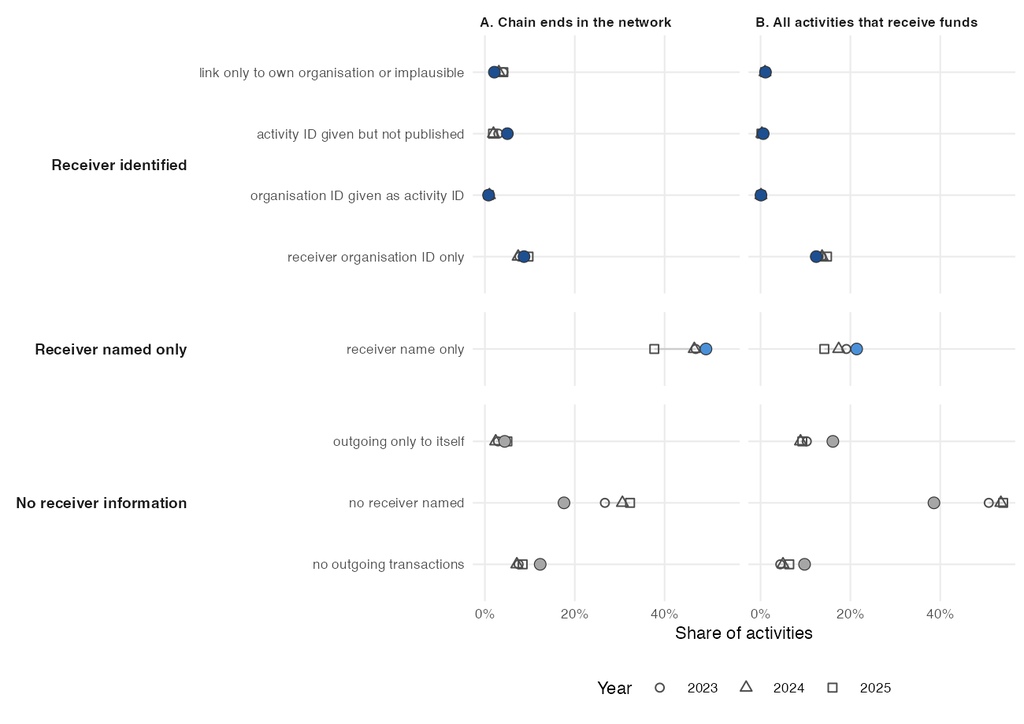

**Figure 13b.** Figure 13b. Why chains stop, by year (Section 6.3): the reasons of Figure 13 for the activities with at least one transaction dated in 2023, 2024 or 2025 (open symbols; year by transaction date), and for all years (filled circle, colored by group as in Figure 13). The reason is judged on all of an activity’s outgoing transactions. n: 2023: 2,241 chain ends, 33,153 receiving activities; 2024: 2,453 chain ends, 36,359 receiving activities; 2025: 1,688 chain ends, 32,139 receiving activities. Unit: activities.

**Interactive**

[interactive chart not shown]

## 6. Organization network and activity network

Organisation IDs connect almost everyone; activity IDs connect few

|  | Organisation network | Activity network | Activity network seen as organisations |
| --- | --- | --- | --- |
| Nodes | 22,523 | 14,716 | 1,062 |
| Links | 28,270 | 13,024 | 1,699 |
| Separate pieces (components) | 43 | 2,602 |  |
| Largest piece | 22,373 | 2,812 |  |

Organization IDs place 99.3% of organizations in one connected network. Only 1,699 of 28,270 organization links (6%) can also be followed through activity IDs. The organization network leaves out 11,240 identifiers that UNICEF gives its own partners (`XM-DAC-41122-VN-…`, `config.PARTNER_CODE_PATTERN`) and their 11,240 links. They publish no activities, so the activity network does not change. The figure shows that traceable part: organizations joined by at least one activity link.

**Figure**

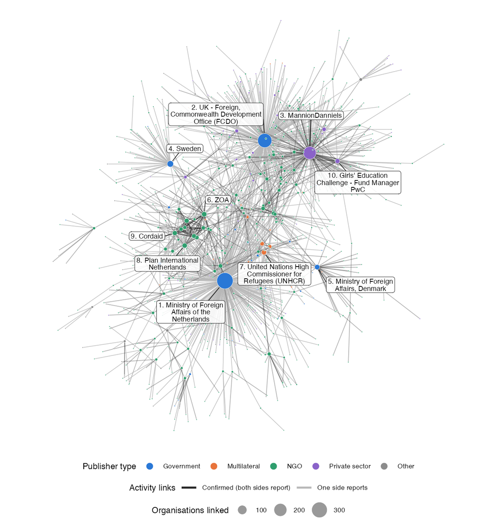

**Figure 6.** Figure 6. Organizations joined by activity links: the largest connected group. Shows the organizations behind indicator 1 of Table 4 (activities connected to an activity of another organization; Section 4.2): each line is a link that makes the activities at both ends count as connected. It is the part of the organization network (Section 3.2) that can be followed activity by activity (the ‘linked’ level of Table 2). The group holds 1,050 of 1,062 organizations and 1,692 organization links. Each circle is an organization, colored by the IATI organization type of its own published data (gray, other types: academic, training and research (73), foundation (44), other public sector (22, including the European Commission services DG INTPA, DG NEAR, ECHO and FPI), the IATI type Other (9), public private partnership (6)). Circle area: number of organizations linked. Each line is at least one activity link between two organizations; dark lines: at least one of those activity links is reported by both sides (377 organization links); light lines: reported by one side only. Numbered labels: the ten organizations linked to most other organizations. Layout: force-directed (Fruchterman-Reingold), so position shows connection, not geography. All years. Unit: organizations; organization links.

**By year**

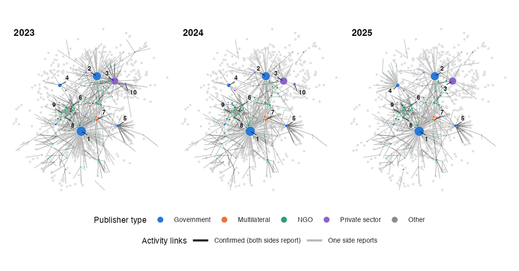

**Figure 6b.** Figure 6b. Organizations joined by activity links, by year (indicator 1 of Table 4 seen by organization, as in Figure 6; Sections 3.2 and 4.2): the group of Figure 6, with organizations in the same positions, showing only the organization links with at least one activity link that has a transaction dated in that year (2023: 473 organizations, 623 links; 2024: 404 organizations, 536 links; 2025: 379 organizations, 484 links). Light gray points: organizations with no such link that year. Colors, line shades and circle area as in Figure 6; numbers are the ten labeled organizations of Figure 6 (most organizations linked). Whether a link is confirmed refers to all years. Years by transaction date; 2025 may rise as receivers report later. Unit: organizations; organization links.

**Interactive**

Zoom with the scroll wheel, drag to move. Hover over an organization to see its name, type and identifier, or select one from the list to highlight its links.

[interactive chart not shown]

### Organizations by publisher type and as intermediaries

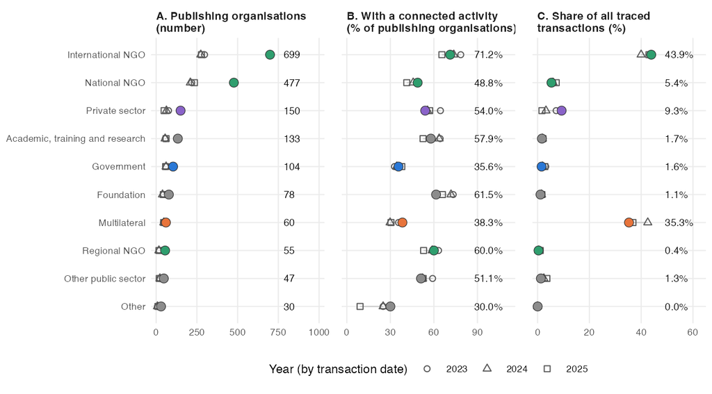

**Figure 4.** Organization level by publisher type. This figure reports the organization-level indicators of Table 4 (Section 2.5) for each publisher type: panel B is indicator 7b (publishing organizations with no connected activity), shown as its complement; panel A is the base of 7b; panel C is D2g, which splits the denominator of indicator D2 (all traced transactions) by publisher type and so shows who holds the traced part of the system that D2 measures as concentrated in ten publishers. Publisher type: IATI organization type of the reporting organization; types with 30 or more publishing organizations across all years (10 types), ordered by that number. Filled circle, and the value printed at the right: all years, colored by publisher type group as in Figures 6 and 7; open symbols: 2023, 2024 and 2025 (transactions by date). A: publishing organizations, meaning reporting organizations with at least one activity with transactions in the period (unit: organizations; the denominator of indicator 7b). B: of these, the share with at least one activity connected to an activity of another organization (100% minus indicator 7b; unit: organizations). C: share of all traced transactions in the period that publishers of the type report; traced transactions name a published counterpart activity of another organization and are not internal (indicator D2g; unit: transactions; the shares of all types, including those not shown, add up to 100%). Fewer than 30 publishing organizations in a year, so the year values in B are based on few organizations: Other 2023 (8); Other public sector 2023 (22); Regional NGO 2023 (19); Other 2024 (8); Other public sector 2024 (23); Regional NGO 2024 (17); Other 2025 (11); Other public sector 2025 (19); Regional NGO 2025 (17).

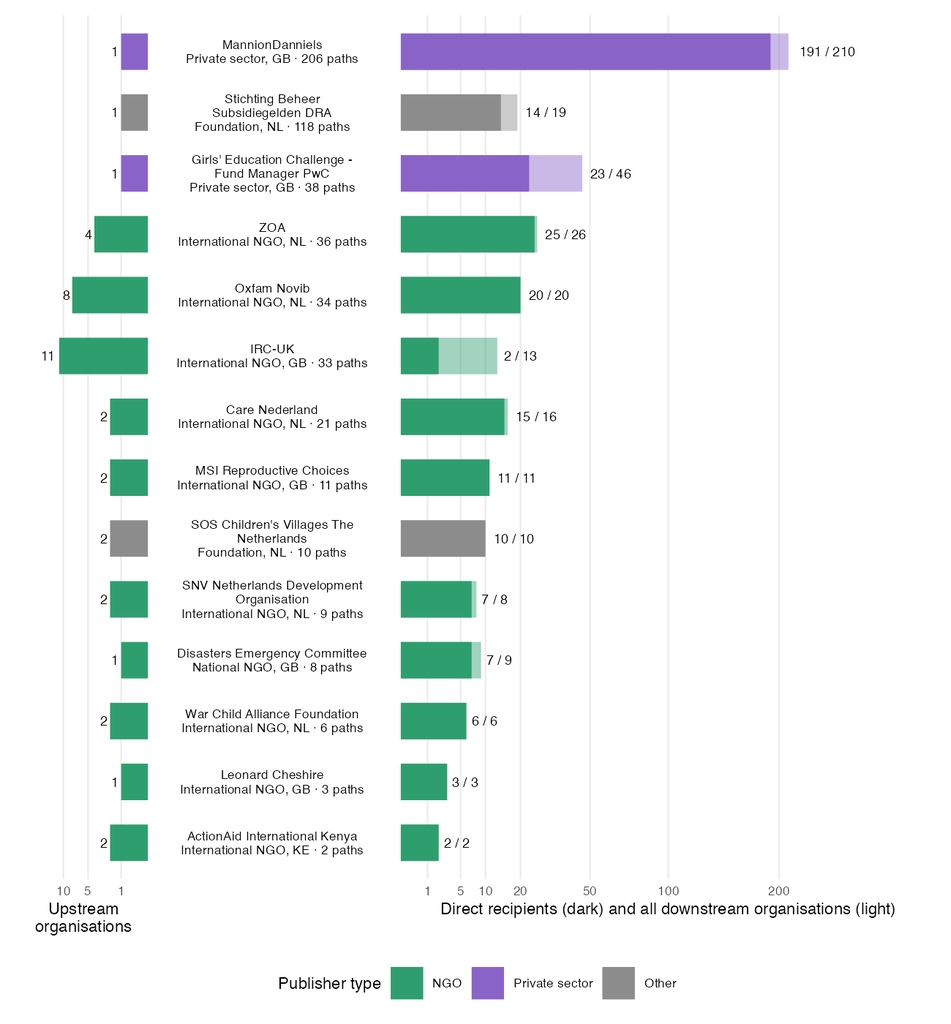

**Figure 5.** Network multipliers: organizations that receive traced funding and pass it on within the same chain. Reports the organization-level measure ‘(multiplier)’ of Table 4 (Section 3.4; values in Table 8), measured on the organization paths of the chain level (indicator 6e). An organization is a multiplier on an organization path if it is neither the first nor the last organization on it; 143 organizations are multipliers on at least one of the 1,785 organization paths (all of them in multipliers_all.csv). Shown: the 14 organizations of Table 8, ordered by the number of organization paths on which they are multipliers (given under each name, with the IATI organization type and country of registration). Left: distinct organizations before it on those paths (upstream). Right, on the same scale: distinct organizations right after it (direct recipients, dark) and all organizations after it (downstream, light); labels give direct / downstream. Counts use only the paths on which the organization is a multiplier, and organizations are identified by their identifier. Bars on a square-root scale. Color: publisher type group as in Figures 6 and 7. All years. Unit: organizations; organization paths.

### Reach, and comparison with McCarthy et al.

Table 7. Organizations that reach furthest through the organization network. Reach score: harmonic centrality, as in McCarthy et al., without their adjustment for network position. Only well-formed identifiers, without UNICEF’s partner codes. Unit: organizations.

| Organisation | Type | Organisations funded | Funded by | Reach score |
| --- | --- | --- | --- | --- |
| UK - Foreign, Commonwealth Development Office (FCDO) | Government | 615 | 10 | 2,008 |
| European Commission - Directorate-General for International Partnerships | Other public sector | 314 | 1 | 1,909 |
| Ministry of Foreign Affairs, Denmark | Government | 619 | 9 | 1,882 |
| Ministry of Foreign Affairs of the Netherlands | Government | 368 | 7 | 1,695 |
| DFAT / Irish Aid | Government | 203 | 1 | 1,646 |
| Directorate-general Development Cooperation and Humanitarian Aid | Government | 137 | 0 | 1,556 |
| European Commission - Directorate-General for Neighbourhood and Enlargement Negotiations | Other public sector | 170 | 0 | 1,447 |
| UK - Department of Health and Social Care (DHSC) | Government | 136 | 1 | 1,401 |
| AICS - Italian Agency for Cooperation and Development | Government | 361 | 1 | 1,376 |
| MSI Reproductive Choices | International NGO | 22 | 7 | 1,362 |

Table 15. The organization network under McCarthy et al.’s definition and under wider ones. Same definition: disbursements reported by the funder, with suffixed identifiers merged as in the paper. Adding receiver reports: also incoming funds reported by the receiver. Units: organizations; links; ordered pairs of organizations.

| Measure | McCarthy et al. | This chapter: same definition | Adding receiver reports | All commitments and disbursements |
| --- | --- | --- | --- | --- |
| Organisations | 22,773 | 15,018 | 17,895 | 21,803 |
| Links | 28,708 | 17,588 | 22,742 | 27,573 |
| Ordered pairs connected (%) | 1.11 | 0.77 | 11.22 | 9.77 |
| Mean distance (steps) | 6.00 | 5.34 | 5.39 | 5.22 |
| Longest path (steps) | 13 | 13 | 14 | 12 |
| Largest connected group (%) | 98.6 | 96.4 | 99.5 | 99.4 |

## 7. Indicators

Indicator definitions, numerators, denominators and units are in `docs/indicators.md`. Rows with a denominator below 30 are flagged `small_base` in `indicators.csv`; their percentages should not be reported.

Indicators, all publishers. Years by transaction date; the network is global.

| indicator | name | unit | 2023 | 2024 | 2025 | Global |
| --- | --- | --- | --- | --- | --- | --- |
| 1 | Activities connected to another IATI activity | activities | 2.7% | 2.6% | 2.1% | 1.8% |
| 2 | Incoming transactions with a valid provider ID | transactions | 67.0% | 64.0% | 66.9% | 62.8% |
| 2b | Incoming: provider ID is a publisher’s identifier not in the codelist | transactions | 7.1% | 7.0% | 5.6% | 5.6% |
| 3 | Outgoing transactions with a valid receiver ID | transactions | 20.5% | 19.9% | 23.7% | 19.8% |
| 3b | Outgoing: receiver ID is a publisher’s identifier not in the codelist | transactions | 0.5% | 0.6% | 0.6% | 0.5% |
| 4 | Counterpart IDs that match an IATI publisher | transactions | 35.3% | 35.1% | 31.8% | 35.1% |
| 5 | Outgoing links to published activities confirmed by the receiver | transactions | 86.5% | 89.5% | 87.8% | 82.7% |
| 6 | Average observable chain depth: longest chain per origin (steps) | origins | 1.1 | 1.09 | 1.12 | 1.09 |
| 6b | Origins whose longest chain has 2+ steps | origins | 8.2% | 7.7% | 10.0% | 7.1% |
| 6c | Longest observed chain (steps) | chains | 5 | 5 | 5 | 5 |
| 6d | Chains with 2+ steps | chains | 22.0% | 14.7% | 15.1% | 13.9% |
| 6e | Organisation paths with 2+ steps | organisation paths | 56.9% | 46.9% | 45.8% | 49.6% |
| 6f | Chain completeness score, mean over chains (tentative) | chains | 0.382 | 0.369 | 0.37 | 0.369 |
| 7a | Isolated activities | activities | 97.3% | 97.4% | 97.9% | 98.2% |
| 7b | Isolated publishing organisations | organisations | 38.2% | 42.9% | 48.2% | 41.6% |
| x1 | Counterpart activity ID given but not published | transactions | 53.0% | 58.9% | 57.0% | 61.1% |
| x1b | Organisation ID given in the activity-ID field | transactions | 59.7% | 58.9% | 50.3% | 47.8% |
| D1 | Exact duplicate transactions (left out) | transactions | 1.6% | 1.5% | 2.1% | 2.0% |
| D1a | Activities with a duplicate copy removed in stage 2 | activities | 0.5% | 0.4% | 0.4% | 0.4% |
| D1b | Outgoing transactions whose flow the receiver also reports (double-count risk) | transactions | 86.5% | 89.5% | 87.8% | 82.7% |
| D2 | Traced transactions held by the top 10 publishers | transactions | 71.2% | 74.8% | 70.6% | 67.6% |
| D2g | Traced transactions held by the publisher group | transactions | 100.0% | 100.0% | 100.0% | 100.0% |

Key indicators (%) by publisher group, global. Small bases are shown as (n = denominator).

| group | 1 | 2 | 3 | 4 | 5 | x1 | activities |
| --- | --- | --- | --- | --- | --- | --- | --- |
| Government | 0.4 | 16.6 | 18 | 29.7 | 86.1 | 98.9 | 481,103 |
| Multilateral | 1.6 | 63.4 | 36 | 34.1 | 98.6 | 48.8 | 160,636 |
| International NGO | 11.5 | 58.3 | 9.7 | 71.2 | 76.6 | 19.1 | 59,689 |
| Other public sector | 2.1 | 86.7 | 12.2 | 71 | 46.9 | 8.7 | 35,496 |
| National NGO | 4.9 | 52 | 6.2 | 74.3 | 56.4 | 56 | 25,021 |
| Foundation | 1.4 | 88 | 10.3 | 18.8 | 57.1 | 56.8 | 15,969 |
| Academic, training and research | 3.1 | 36.1 | 53.4 | 44.3 | 27.9 | 30.8 | 7,361 |
| Private sector | 6.7 | 78.6 | 26.1 | 67.3 | 39.5 | 40.2 | 5,268 |
| Public private partnership | 0.3 | 15.5 | 0 | (n=28) | (n=0) | (n=22) | 2,761 |
| Other | 1.4 | 45.3 | 0 | 70.9 | (n=0) | 39.3 | 850 |
| Regional NGO | 17 | 73 | 4.8 | 70.5 | (n=18) | 18.1 | 440 |
| Private sector (provider country) | (n=11) | 70.5 | (n=17) | 96.6 | (n=0) | 33.3 | 11 |
| Partner country based NGO | (n=5) | (n=5) | (n=4) | (n=5) | (n=0) | (n=7) | 5 |
| Private sector (recipient country) | (n=4) | (n=17) | (n=0) | (n=17) | (n=0) | (n=19) | 4 |
| Private sector (third country) | (n=2) | (n=7) | (n=0) | (n=4) | (n=0) | (n=4) | 2 |

**Sensitivity to the open questions.** Each setting was switched in turn and stage 5 rerun (`report/sensitivity.py`; results in `sensitivity.csv`).

**Disbursements only.** By default, outgoing flows pool commitments and disbursements (types 2 and 3), and incoming flows pool incoming funds and incoming commitments (types 1 and 11). The McCarthy paper uses disbursements only. In this alternative, outgoing flows are disbursements (type 3) and incoming flows are incoming funds (type 1). Because this changes which links exist, the links, the network and the chains were rebuilt (stages 3–5, in `sensitivity_disbursements_only/`), so indicators 1 and 6 change too.

Main indicators (% ; indicator 6 in steps) under each alternative setting. Each row changes one setting from the default. Units: 1 activities; 2 to 5, x1 and x1b transactions; 6 origins.

| setting | scope | 1 | 2 | 3 | 4 | 5 | x1 | x1b | 6 |
| --- | --- | --- | --- | --- | --- | --- | --- | --- | --- |
| None (default) | 2025 | 2.1 | 66.9 | 23.7 | 31.8 | 87.8 | 57.0 | 50.3 | 1.12 |
| None (default) | Global | 1.8 | 62.8 | 19.8 | 35.1 | 82.7 | 61.1 | 47.8 | 1.09 |
| Expenditure counted in 3, 4, x1 | 2025 | 2.1 | 66.9 | 14.4 | 31.6 | 87.8 | 57.3 | 50.0 | 1.12 |
| Expenditure counted in 3, 4, x1 | Global | 1.8 | 62.8 | 14.1 | 33.9 | 82.7 | 62.1 | 47.3 | 1.09 |
| Related-activity links, other publishers | 2025 | 3.0 | 66.9 | 23.7 | 31.8 | 87.8 | 57.0 | 50.3 | 1.12 |
| Related-activity links, other publishers | Global | 2.1 | 62.8 | 19.8 | 35.1 | 82.7 | 61.1 | 47.8 | 1.09 |
| Related-activity links, all | 2025 | 30.6 | 66.9 | 23.7 | 31.8 | 87.8 | 57.0 | 50.3 | 1.12 |
| Related-activity links, all | Global | 33.0 | 62.8 | 19.8 | 35.1 | 82.7 | 61.1 | 47.8 | 1.09 |
| Year by activity period | 2025 | 2.1 | 67.0 | 28.3 | 39.5 | 87.7 | 50.9 | 47.4 | 1.11 |
| Year by activity period | Global | 1.8 | 62.8 | 19.8 | 35.1 | 82.7 | 61.1 | 47.8 | 1.09 |
| Disbursements only (network rebuilt) | 2025 | 1.7 | 64.4 | 27.9 | 33.3 | 67.3 | 56.0 | 55.8 | 1.13 |
| Disbursements only (network rebuilt) | Global | 1.4 | 61.7 | 23.4 | 36.5 | 58.8 | 58.7 | 49.8 | 1.13 |

### Link quality by publisher type

**Figure**

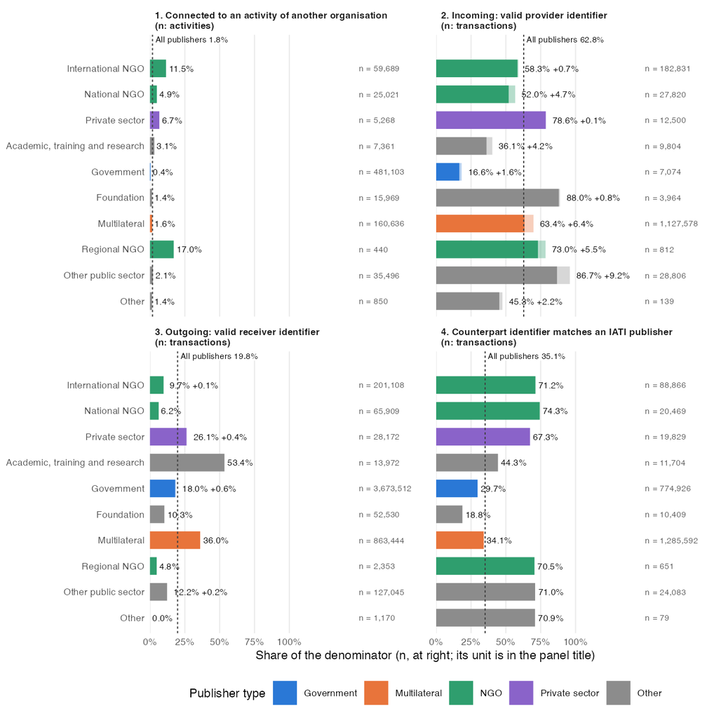

**Figure 7.** Figure 7. Link quality by publisher type, all years. Reports, for each publisher type, the activity-level indicator 1 (Table 4; Section 4.2) and the transaction-level indicators 2, 2b, 3, 3b and 4 (Table 4; Section 5.2), which follow the link quality tests of Table 2 (identified: 2, 2b, 3, 3b; matched: 4; linked: 1). Publisher type: IATI organization type of the reporting organization; the 10 types with 30 or more publishing organizations, ordered by that number (largest first; the same order in every panel and in the organization-level figure). Panel 1: activities connected to an activity of another organization (indicator 1; unit: activities). Panel 2: incoming transactions with a valid provider identifier (indicator 2; unit: transactions); the lighter segment adds those naming a publisher’s own identifier outside the codelist (indicator 2b). Panel 3: outgoing commitments and disbursements with a valid receiver identifier (indicator 3; unit: transactions); lighter segment: indicator 3b. Panel 4: counterpart identifiers that match an IATI publisher (indicator 4; unit: transactions). Labels: the indicator, then the 2b or 3b share; n: the denominator, in the unit given in the panel title. Dashed line: all publishers (1: 1.8%; 2: 62.8%; 3: 19.8%; 4: 35.1%). Color: publisher type group as in Figure 6. All years.

**By year**

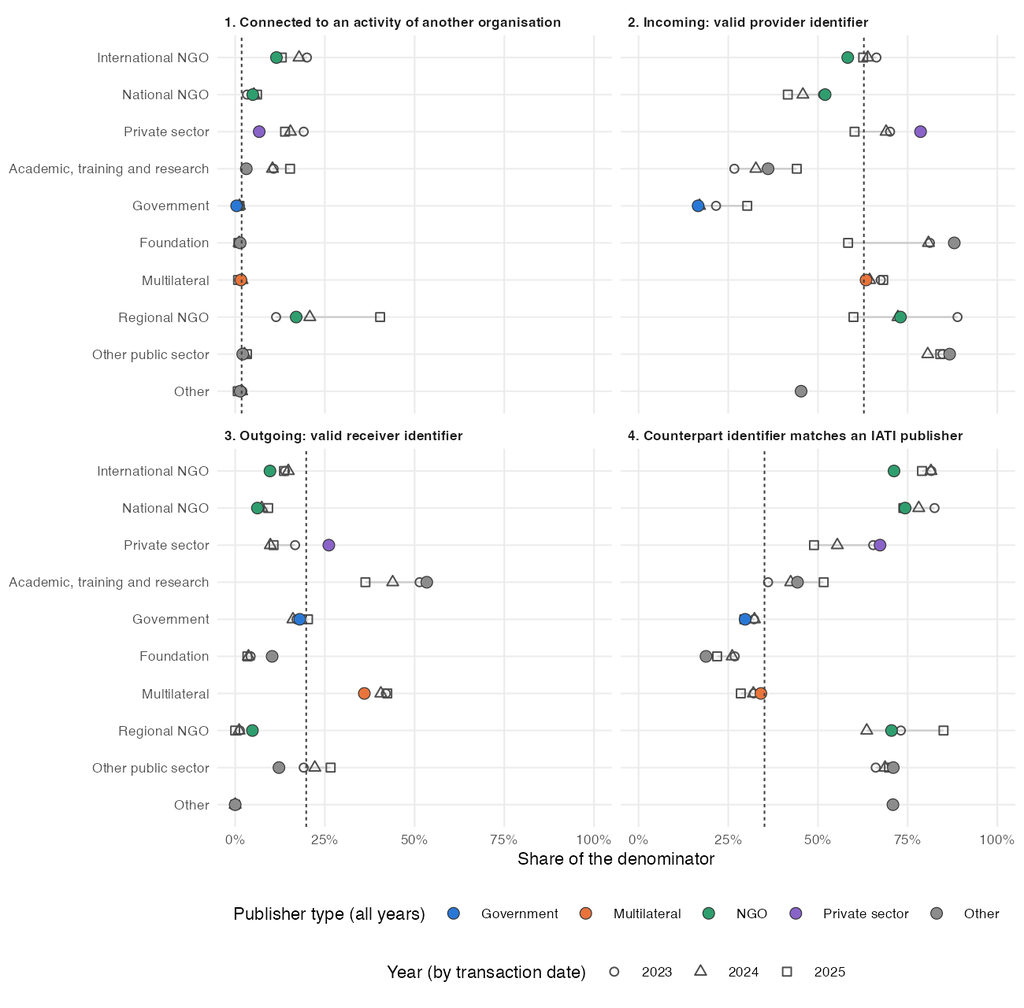

**Figure 7b.** Figure 7b. Link quality by publisher type and year: the Table 4 indicators 1 (Section 4.2), 2, 3 and 4 (Section 5.2) as in Figure 7, by year, for transactions dated 2023, 2024 and 2025 (open symbols; for indicator 1, activities with a transaction in the year) and for all years (filled circle, colored by publisher type group). Publisher types and order as in Figure 7. Dashed line: all publishers, all years. 2b and 3b are not shown by year (values in wp_numbers.csv). Units: indicator 1, activities; indicators 2 to 4, transactions. Not shown, denominator below 30: Other 2023 (indicator 2); Other 2023 (indicator 4); Other 2024 (indicator 2); Other 2024 (indicator 4); Other 2025 (indicator 2); Other 2025 (indicator 4).

### Indicator 3 for each publisher

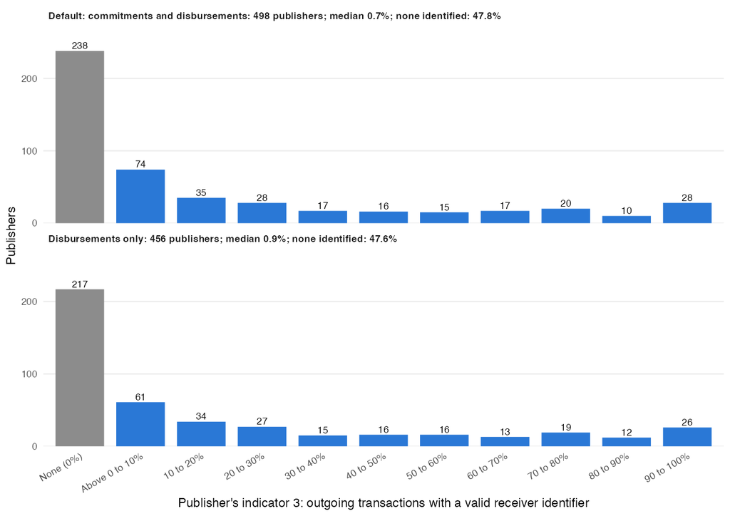

**Figure 8.** Indicator 3 for each publisher (Table 4, transaction level, Section 5.2; the publisher-level view that Section 8.1 compares with McCarthy et al., 2026). Each bar counts publishers (reporting organizations) by the share of their outgoing transactions that give a valid receiver identifier; gray: publishers that identify no receiver. Top: the default (commitments and disbursements pooled), publishers with 30 or more such transactions. Bottom: disbursements only (type 3), publishers with 30 or more disbursements. Counts of transactions, before any matching of receiver names, so each publisher counts once whatever its size; the largest, US-GOV-1 (1,818,908 outgoing transactions), gives receiver names but no receiver organization identifier on any of them. All years. Unit: publishers; transactions. McCarthy et al. report a median funder identification rate of 7.7% and 46.3% of funders identifying no receiver, by value and after name matching, so the figures are not directly comparable.

### Indicator 4 in 2025

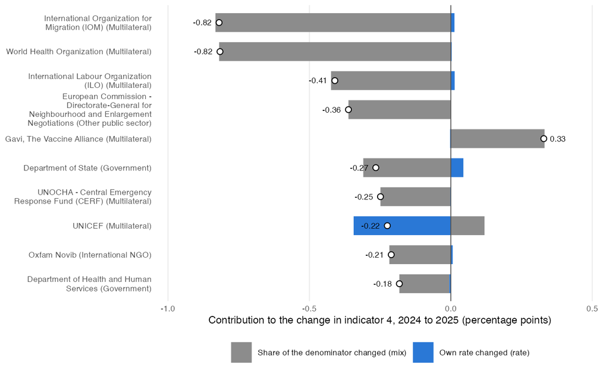

**Figure 9.** Indicator 4 in 2025: the ten publishers that contribute most to the change. Indicator 4 (Table 4, transaction level, Section 5.2: counterpart identifiers that match an IATI publisher) is 31.8% for transactions dated 2025 against 35.1% for 2024 (-3.35 points). Each publisher’s contribution (circle and label, percentage points) is its matched transactions as a share of all transactions in the denominator in 2025 minus the same for 2024; the contributions of all publishers add up to the change. Bars split it into the part due to a change in the publisher’s share of the denominator (mix, gray) and the part due to a change in its own rate (rate, blue). The four largest contributions make up 71.8% of the change. Years by transaction date. Unit: transactions; percentage points. Method and full table: docs/indicator4_2025_check.md.

### Reporting lag

Reporting lag check: indicators 1, 5 and 7b by year, as published and as a lower bound without later confirmations (report/reporting_lag_check.R).

| year | ind1_base | ind1_lb | ind1_num | ind1_num_lb | ind1_den | ind7b_base | ind7b_lb | ind7b_num | ind7b_num_lb | ind7b_den | ind5_base | ind5_lb | ind5_num | ind5_num_lb | ind5_den | late_links | links_Y | links_Y_confirmed | links_Y_conf_late | conf_late_pct | recv_updated_after_pct |
| --- | --- | --- | --- | --- | --- | --- | --- | --- | --- | --- | --- | --- | --- | --- | --- | --- | --- | --- | --- | --- | --- |
| 2023 | 2.7 | 2.6 | 3490 | 3404 | 131258 | 38.2 | 38.8 | 321 | 326 | 841 | 86.5 | 85.4 | 1610 | 1590 | 1861 | 849 | 2240 | 2162 | 7 | 0.3 | 95.2 |
| 2024 | 2.6 | 2.5 | 3583 | 3536 | 138810 | 42.9 | 43.2 | 342 | 344 | 797 | 89.5 | 87.9 | 1336 | 1313 | 1493 | 381 | 2423 | 2371 | 4 | 0.2 | 95.6 |

**Explore all indicators.** Every row of `indicators.csv`, with search and column filters.

| scope | group | indicator | name | unit | numerator | denominator | percent | value | small_base |
| --- | --- | --- | --- | --- | --- | --- | --- | --- | --- |
| UG_2025 | Academic, training and research | 1 | Activities connected to another IATI activity | activities | 9 | 51 | 17.6 |  | False |
| UG_2025 | Academic, training and research | 2 | Incoming transactions with a valid provider ID | transactions | 20 | 64 | 31.2 |  | False |
| UG_2025 | Academic, training and research | 2b | Incoming: provider ID is a publisher's identifier not in the codelist | transactions | 1 | 64 | 1.6 |  | False |
| UG_2025 | Academic, training and research | 3 | Outgoing transactions with a valid receiver ID | transactions | 42 | 114 | 36.8 |  | False |
| UG_2025 | Academic, training and research | 3b | Outgoing: receiver ID is a publisher's identifier not in the codelist | transactions | 0 | 114 | 0 |  | False |
| UG_2025 | Academic, training and research | 4 | Counterpart IDs that match an IATI publisher | transactions | 30 | 60 | 50 |  | False |
| UG_2025 | Academic, training and research | 5 | Outgoing links to published activities confirmed by the receiver | transactions | 0 | 0 |  |  | True |
| UG_2025 | Academic, training and research | 6 | Average observable chain depth: longest chain per origin (steps) | origins |  | 1 |  | 1 | True |
| UG_2025 | Academic, training and research | 6b | Origins whose longest chain has 2+ steps | origins | 0 | 1 | 0 |  | True |
| UG_2025 | Academic, training and research | 6c | Longest observed chain (steps) | chains |  | 1 |  | 1 | True |

[output cut: 1120 more lines]

## 8. Example chains, with the XML behind each step

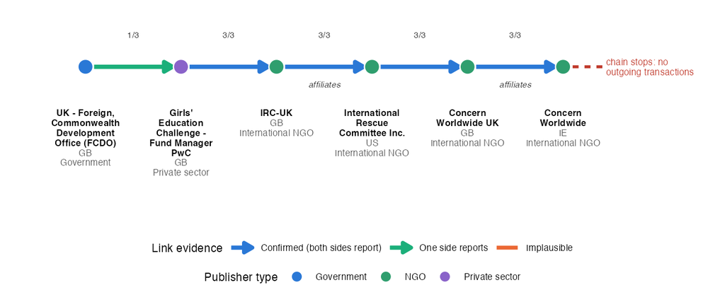

**Figure 11.** Figure 11. The longest organization path (5 steps; indicator 6c of Table 4, Section 6.2), drawn through its most complete chain (chain 3431, completeness score 0.867; years 2018-2023). 4 of its 5 steps are confirmed by both sides. Each circle is an organization, colored by publisher type group (as in Figures 6 and 7), with its full name, country of registration and IATI organization type. Arrows: activity links, colored by evidence (blue: confirmed by both funder and receiver; green: reported by one side; orange: implausible), the same colors in every chain figure. The fraction above each arrow (1/3, 2/3 or 3/3) counts how many of three pieces of information the link has: (1) the funder’s payment record gives the receiving organization’s identifier; (2) it gives the identifier of the receiver’s activity (project), which the receiver publishes; (3) the receiver also reports the money coming in, naming the funder’s activity. 3/3 means all three; 1/3 usually means only the receiver reports the link. These are the points of the chain completeness score (tentative indicator 6f, which may be removed). ‘Affiliates’ under an arrow: the two organizations are separately registered branches of the same organization, often in different countries (for example IRC-UK and the International Rescue Committee Inc. in the United States; Concern Worldwide UK and Concern Worldwide in Ireland). Funding between them is a real transfer, but not a step towards a different, local organization. They are found by name, because the data hold no field for this: the names are the same after dropping country and legal-form words (UK, Inc., Ltd, Limited, USA, GB), or they share a distinctive first word, or one name starts with an acronym of the other (IRC for International Rescue Committee). Unit: organizations; activity links.

**Example chains**

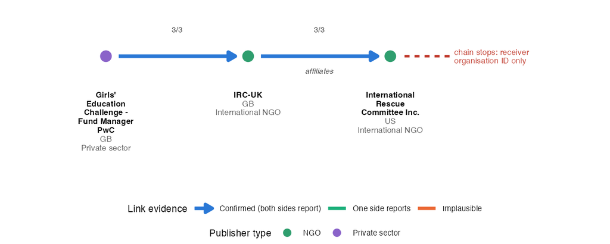

**Figure 12.** Example chain 1: Confirmed at every step (example_chains.json; chosen by report/example_chains.py: The longest chain whose every link is reported by both the funder and the receiver.). Chain 4108, 2 step(s), completeness score 1, years 2013-2019. Relates to the chain-level indicators of Table 4 (Section 6.2) and Table 2’s link quality levels. Each circle is an organization, colored by publisher type group (as in Figures 6 and 7), with its full name, country of registration and IATI organization type. Arrows: activity links, colored by evidence (blue: confirmed by both funder and receiver; green: reported by one side; orange: implausible), the same colors in every chain figure. The fraction above each arrow (1/3, 2/3 or 3/3) counts how many of three pieces of information the link has: (1) the funder’s payment record gives the receiving organization’s identifier; (2) it gives the identifier of the receiver’s activity (project), which the receiver publishes; (3) the receiver also reports the money coming in, naming the funder’s activity. 3/3 means all three; 1/3 usually means only the receiver reports the link. These are the points of the chain completeness score (tentative indicator 6f, which may be removed). ‘Affiliates’ under an arrow: the two organizations are separately registered branches of the same organization, often in different countries (for example IRC-UK and the International Rescue Committee Inc. in the United States; Concern Worldwide UK and Concern Worldwide in Ireland). Funding between them is a real transfer, but not a step towards a different, local organization. They are found by name, because the data hold no field for this: the names are the same after dropping country and legal-form words (UK, Inc., Ltd, Limited, USA, GB), or they share a distinctive first word, or one name starts with an acronym of the other (IRC for International Rescue Committee). Unit: organizations; activity links.

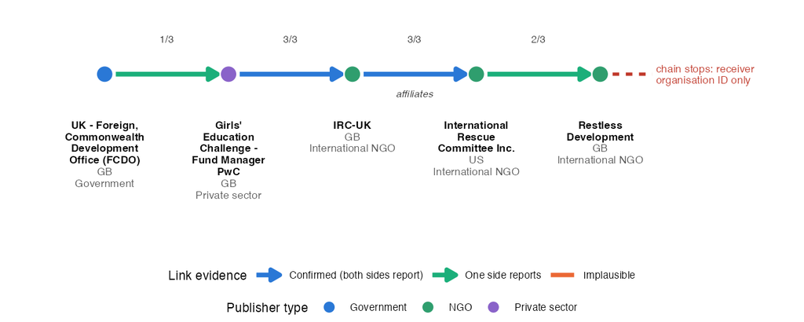

**Figure 14.** Example chain 2: Broken by a missing activity ID (example_chains.json; chosen by report/example_chains.py: The chain stops because the last activity pays an organization identified by its ID, but gives no activity ID, so the money cannot be followed further.). Chain 3433, 4 step(s), completeness score 0.75, years 2018-2025. Relates to the chain-level indicators of Table 4 (Section 6.2) and Table 2’s link quality levels. Each circle is an organization, colored by publisher type group (as in Figures 6 and 7), with its full name, country of registration and IATI organization type. Arrows: activity links, colored by evidence (blue: confirmed by both funder and receiver; green: reported by one side; orange: implausible), the same colors in every chain figure. The fraction above each arrow (1/3, 2/3 or 3/3) counts how many of three pieces of information the link has: (1) the funder’s payment record gives the receiving organization’s identifier; (2) it gives the identifier of the receiver’s activity (project), which the receiver publishes; (3) the receiver also reports the money coming in, naming the funder’s activity. 3/3 means all three; 1/3 usually means only the receiver reports the link. These are the points of the chain completeness score (tentative indicator 6f, which may be removed). ‘Affiliates’ under an arrow: the two organizations are separately registered branches of the same organization, often in different countries (for example IRC-UK and the International Rescue Committee Inc. in the United States; Concern Worldwide UK and Concern Worldwide in Ireland). Funding between them is a real transfer, but not a step towards a different, local organization. They are found by name, because the data hold no field for this: the names are the same after dropping country and legal-form words (UK, Inc., Ltd, Limited, USA, GB), or they share a distinctive first word, or one name starts with an acronym of the other (IRC for International Rescue Committee). Unit: organizations; activity links.

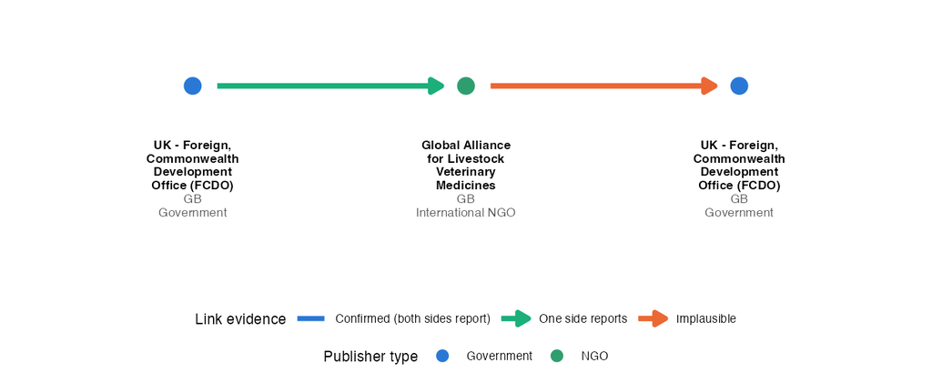

**Figure A.1.** Example chain 3: Implausible link (example_chains.json; chosen by report/example_chains.py: A publisher puts its funder’s activity ID in receiver-activity-id on payments to others. Read literally, money flows back to the funder and the two activities form a loop. The rule ‘reverses own funding link’ flags the second link; the first (true) link is kept.). Not a chain in the network: an implausible link is set aside before chains are built (Annex A.4). Relates to the chain-level indicators of Table 4 (Section 6.2) and Table 2’s link quality levels. Each circle is an organization, colored by publisher type group (as in Figures 6 and 7), with its full name, country of registration and IATI organization type. Arrows: activity links, colored by evidence (blue: confirmed by both funder and receiver; green: reported by one side; orange: implausible), the same colors in every chain figure. ‘Affiliates’ under an arrow: the two organizations are separately registered branches of the same organization, often in different countries (for example IRC-UK and the International Rescue Committee Inc. in the United States; Concern Worldwide UK and Concern Worldwide in Ireland). Funding between them is a real transfer, but not a step towards a different, local organization. They are found by name, because the data hold no field for this: the names are the same after dropping country and legal-form words (UK, Inc., Ltd, Limited, USA, GB), or they share a distinctive first word, or one name starts with an acronym of the other (IRC for International Rescue Committee). Unit: organizations; activity links.

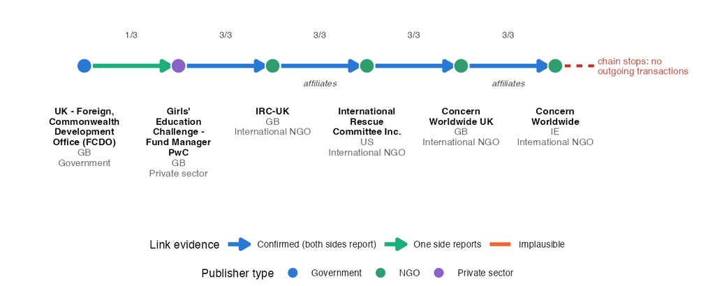

Example chain 4: Longest chain (example_chains.json; chosen by report/example_chains.py: The longest chain in the network.). Chain 3431, 5 step(s), completeness score 0.867, years 2018-2023. Relates to the chain-level indicators of Table 4 (Section 6.2) and Table 2’s link quality levels. Each circle is an organization, colored by publisher type group (as in Figures 6 and 7), with its full name, country of registration and IATI organization type. Arrows: activity links, colored by evidence (blue: confirmed by both funder and receiver; green: reported by one side; orange: implausible), the same colors in every chain figure. The fraction above each arrow (1/3, 2/3 or 3/3) counts how many of three pieces of information the link has: (1) the funder’s payment record gives the receiving organization’s identifier; (2) it gives the identifier of the receiver’s activity (project), which the receiver publishes; (3) the receiver also reports the money coming in, naming the funder’s activity. 3/3 means all three; 1/3 usually means only the receiver reports the link. These are the points of the chain completeness score (tentative indicator 6f, which may be removed). ‘Affiliates’ under an arrow: the two organizations are separately registered branches of the same organization, often in different countries (for example IRC-UK and the International Rescue Committee Inc. in the United States; Concern Worldwide UK and Concern Worldwide in Ireland). Funding between them is a real transfer, but not a step towards a different, local organization. They are found by name, because the data hold no field for this: the names are the same after dropping country and legal-form words (UK, Inc., Ltd, Limited, USA, GB), or they share a distinctive first word, or one name starts with an acronym of the other (IRC for International Rescue Committee). Unit: organizations; activity links.

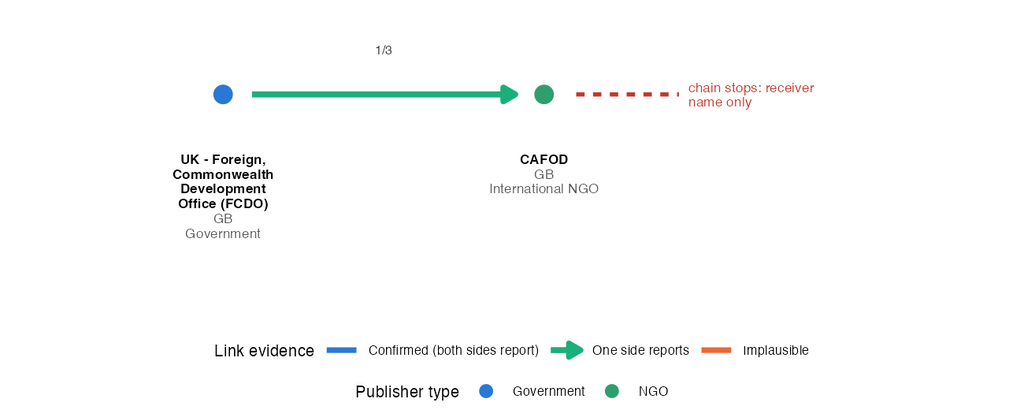

**Figure A.2.** Example chain 5: One origin, many chains (example_chains.json; chosen by report/example_chains.py: This origin activity starts 2,206 chains. Each counts as a separate chain, but all follow few organization paths. This is why depth per chain and per organization path differ.). Chain 652, 1 step(s), completeness score 0.333, years 2010. Relates to the chain-level indicators of Table 4 (Section 6.2) and Table 2’s link quality levels. Each circle is an organization, colored by publisher type group (as in Figures 6 and 7), with its full name, country of registration and IATI organization type. Arrows: activity links, colored by evidence (blue: confirmed by both funder and receiver; green: reported by one side; orange: implausible), the same colors in every chain figure. The fraction above each arrow (1/3, 2/3 or 3/3) counts how many of three pieces of information the link has: (1) the funder’s payment record gives the receiving organization’s identifier; (2) it gives the identifier of the receiver’s activity (project), which the receiver publishes; (3) the receiver also reports the money coming in, naming the funder’s activity. 3/3 means all three; 1/3 usually means only the receiver reports the link. These are the points of the chain completeness score (tentative indicator 6f, which may be removed). ‘Affiliates’ under an arrow: the two organizations are separately registered branches of the same organization, often in different countries (for example IRC-UK and the International Rescue Committee Inc. in the United States; Concern Worldwide UK and Concern Worldwide in Ireland). Funding between them is a real transfer, but not a step towards a different, local organization. They are found by name, because the data hold no field for this: the names are the same after dropping country and legal-form words (UK, Inc., Ltd, Limited, USA, GB), or they share a distinctive first word, or one name starts with an acronym of the other (IRC for International Rescue Committee). Unit: organizations; activity links.

**Counter-example**

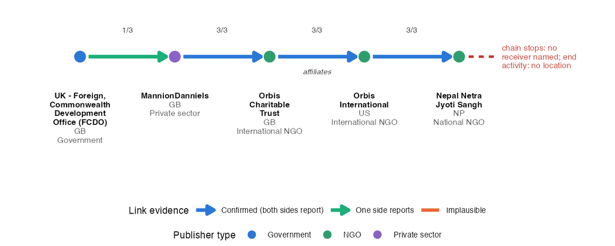

**Figure 22.** Counter-example chain (Figure 21; Section 7.4): chain 3100, 4 steps, completeness score 0.833, years 2018-2023. The best-ranked chain of two or more steps whose end activity has no usable location point (selection rule in Annex A.8). Each circle is an organization, colored by publisher type group (as in Figures 6 and 7), with its full name, country of registration and IATI organization type. Arrows: activity links, colored by evidence (blue: confirmed by both funder and receiver; green: reported by one side; orange: implausible), the same colors in every chain figure. The fraction above each arrow (1/3, 2/3 or 3/3) counts how many of three pieces of information the link has: (1) the funder’s payment record gives the receiving organization’s identifier; (2) it gives the identifier of the receiver’s activity (project), which the receiver publishes; (3) the receiver also reports the money coming in, naming the funder’s activity. 3/3 means all three; 1/3 usually means only the receiver reports the link. These are the points of the chain completeness score (tentative indicator 6f, which may be removed). ‘Affiliates’ under an arrow: the two organizations are separately registered branches of the same organization, often in different countries (for example IRC-UK and the International Rescue Committee Inc. in the United States; Concern Worldwide UK and Concern Worldwide in Ireland). Funding between them is a real transfer, but not a step towards a different, local organization. They are found by name, because the data hold no field for this: the names are the same after dropping country and legal-form words (UK, Inc., Ltd, Limited, USA, GB), or they share a distinctive first word, or one name starts with an acronym of the other (IRC for International Rescue Committee). Unit: organizations; activity links.

**A traceable and a broken chain**

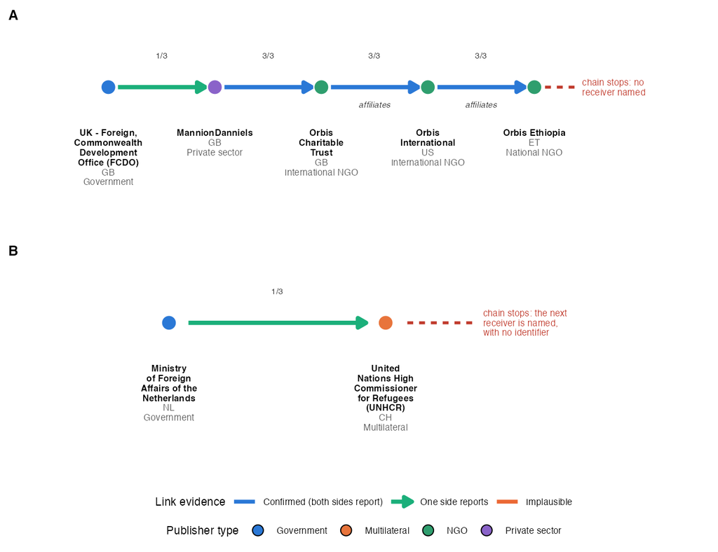

**Figure 2.** A traceable and a broken chain in the same sector and recipient country (Section 1.4 and Figure 2; chain-level indicators of Table 4, Section 6). Sector: DAC 151 (activity-level sector of each chain’s origin activity); country: ET. A: the most traceable chain under the selection rule (chain 359, 4 steps, 3 confirmed by both sides, completeness score 0.833, years 2016-2023; origin value: no commitments or disbursements reported). B: a chain from the same sector that reaches the same country but stops where the next receiver is named, with no identifier (chain 12012, 1 step(s), completeness score 0.333, years 2023; origin value: EUR 124,035,982 commitments). Selection rule (report/case_pair.py): A has 3 or more steps, a completeness score of at least 0.75 (no such chain reaches 1), ends at a national or local implementer, and starts preferably at the Netherlands MFA or UK FCDO; B has the same sector and country, stops at a name-only receiver or an unpublished activity identifier, and has the largest origin value (in its own currency, never converted). Each circle is an organization, colored by publisher type group (as in Figures 6 and 7), with its full name, country of registration and IATI organization type. Arrows: activity links, colored by evidence (blue: confirmed by both funder and receiver; green: reported by one side; orange: implausible), the same colors in every chain figure. The fraction above each arrow (1/3, 2/3 or 3/3) counts how many of three pieces of information the link has: (1) the funder’s payment record gives the receiving organization’s identifier; (2) it gives the identifier of the receiver’s activity (project), which the receiver publishes; (3) the receiver also reports the money coming in, naming the funder’s activity. 3/3 means all three; 1/3 usually means only the receiver reports the link. These are the points of the chain completeness score (tentative indicator 6f, which may be removed). ‘Affiliates’ under an arrow: the two organizations are separately registered branches of the same organization, often in different countries (for example IRC-UK and the International Rescue Committee Inc. in the United States; Concern Worldwide UK and Concern Worldwide in Ireland). Funding between them is a real transfer, but not a step towards a different, local organization. They are found by name, because the data hold no field for this: the names are the same after dropping country and legal-form words (UK, Inc., Ltd, Limited, USA, GB), or they share a distinctive first word, or one name starts with an acronym of the other (IRC for International Rescue Committee). Unit: organizations; activity links.

**The XML behind each step**

**1. Confirmed at every step**

The longest chain whose every link is reported by both the funder and the receiver.

**Path:** Girls’ Education Challenge - Fund Manager PwC > IRC-UK > International Rescue Committee Inc.

**Step 1:** Girls’ Education Challenge - Fund Manager PwC → IRC-UK (confirmed; org matches)

Reported by the funder in 21 transaction(s). First one, `datasets/gecfundmanagerpwc/gecfundmanagerpwc-gec1.xml` line 8218:

```xml
<transaction ref="FMFR003">
      <provider-org provider-activity-id="GB-COH-03580586-GEC-Recipient-5097" ref="GB-COH-03580586-GEC">Girls Education Challenge  Fund Manager PwC</provider-org>
      <receiver-org receiver-activity-id="GB-CHC-1065972-DF080" ref="GB-COH-1065972">International Rescue Commitee UK (IRC UK)</receiver-org>
      <value value-date="2013-04-25">2227987</value>
      <transaction-date iso-date="2013-04-25">25/04/2013</transaction-date>
      <transaction-type code="D"/>
      <description>PWC GEC FUND PAYMENT TO RECIPIENT(IRC UK)</description>
    </transaction>
```

Reported by the receiver in 16 transaction(s). First one, `datasets/irc_uk/irc_uk-activity.xml` line 2:

```xml
<transaction>      <transaction-type code="1"/>      <transaction-date iso-date="2013-04-25"/>      <value currency="GBP" value-date="2013-04-25">2227987</value>      <description>        <narrative>Mobilisation Payment - Receipt of funds</narrative>      </description>      <provider-org ref="GB-COH-03580586-GEC" provider-activity-id="GB-COH-03580586-GEC-Recipient-5097" type="70">        <narrative>GirlsÕ Education Challenge Ð Fund Manager PwC</narrative>      </provider-org>      <receiver-org ref="GB-CHC-1065972" receiver-activity-id="GB-CHC-1065972-DF080" type="21">        <narrative>International Rescue Committee UK</narrative>      </receiver-org>    </transaction>
```

**Step 2:** IRC-UK → International Rescue Committee Inc. (confirmed; org matches)

Reported by the funder in 22 transaction(s). First one, `datasets/irc_uk/irc_uk-activity.xml` line 2:

```xml
<transaction>      <transaction-type code="3"/>      <transaction-date iso-date="2019-02-28"/>      <value currency="GBP" value-date="2019-02-28">238897</value>      <description>        <narrative>Disbursement to IRC Inc.</narrative>      </description>      <provider-org ref="GB-CHC-1065972" provider-activity-id="GB-CHC-1065972-DF080" type="21">        <narrative>IRC UK</narrative>      </provider-org>      <receiver-org ref="US-EIN-13-5660870" receiver-activity-id="US-EIN-13-5660870-DF080" type="21">        <narrative>IRC Inc.</narrative>      </receiver-org>    </transaction>
```

Reported by the receiver in 38 transaction(s). First one, `datasets/irc_inc/irc_inc-activity.xml` line 2:

```xml
<transaction>      <transaction-type code="1"/>      <transaction-date iso-date="2013-05-21"/>      <value currency="USD" value-date="2013-05-21">165946.00</value>      <description>        <narrative>Incoming Funds from IRC UK</narrative>      </description>      <provider-org ref="GB-CHC-1065972" provider-activity-id="GB-CHC-1065972-DF080" type="21">        <narrative>International Rescue Committee UK</narrative>      </provider-org>      <receiver-org ref="US-EIN-13-5660870" receiver-activity-id="US-EIN-13-5660870-DF080" type="21">        <narrative>International Rescue Committee Inc.</narrative>      </receiver-org>    </transaction>
```

**2. Broken by a missing activity ID**

The chain stops because the last activity pays an organisation identified by its ID, but gives no activity ID, so the money cannot be followed further.

**Path:** UK - Foreign, Commonwealth Development Office (FCDO) > Girls’ Education Challenge - Fund Manager PwC > IRC-UK > International Rescue Committee Inc. > Restless Development

**Step 1:** UK - Foreign, Commonwealth Development Office (FCDO) → Girls’ Education Challenge - Fund Manager PwC (one-sided; org matches)

Reported by the receiver in 2 transaction(s). First one, `datasets/gecfundmanagerpwc/gecfundmanagerpwc-activities.xml` line 7825:

```xml
<transaction ref="LNGB Budget Commitment">
      <transaction-type code="11"/>
      <transaction-date iso-date="2018-08-01"/>
      <value value-date="2018-08-01">106462980</value>
      <description>
        <narrative>LNGB Portfolio Budget Commitment from FCDO</narrative>
      </description>
      <provider-org ref="GB-GOV-1" provider-activity-id="GB-1-204766-101" type="10">
        <narrative>FCDO</narrative>
      </provider-org>
      <receiver-org ref="GB-COH-03580586-GEC" receiver-activity-id="GB-COH-03580586-GEC-LNGB" type="70">
        <narrative>PwC</narrative>
      </receiver-org>
    </transaction>
```

**Step 2:** Girls’ Education Challenge - Fund Manager PwC → IRC-UK (confirmed; org matches)

Reported by the funder in 16 transaction(s). First one, `datasets/gecfundmanagerpwc/gecfundmanagerpwc-activities.xml` line 8175:

```xml
<transaction ref="Disbursement 26">
      <transaction-type code="3"/>
      <transaction-date iso-date="2019-07-01"/>
      <value value-date="2019-07-01">361938</value>
      <description>
        <narrative>Outgoing Disbursement - Q3 - LNGB Payment to International Rescue Committee Sierra Leone</narrative>
      </description>
      <provider-org ref="GB-COH-03580586-GEC" provider-activity-id="GB-COH-03580586-GEC-LNGB" type="70">
        <narrative>PwC</narrative>
      </provider-org>
      <receiver-org ref="GB-CHC-1065972" receiver-activity-id="GB-CHC-1065972-DF204" type="21">
        <narrative>International Rescue Committee Sierra Leone</narrative>
      </receiver-org>
    </transaction>
```

Reported by the receiver in 15 transaction(s). First one, `datasets/irc_uk/irc_uk-activity.xml` line 2:

```xml
<transaction>      <transaction-type code="1"/>      <transaction-date iso-date="2020-06-30"/>      <value currency="GBP" value-date="2020-06-30">937749</value>      <provider-org ref="GB-COH-03580586-GEC" provider-activity-id="GB-COH-03580586-GEC-LNGB" type="70">        <narrative>PwC</narrative>      </provider-org>      <receiver-org ref="GB-CHC-1065972" receiver-activity-id="GB-CHC-1065972-DF204" type="21">        <narrative>International Rescue Committee UK</narrative>      </receiver-org>    </transaction>
```

**Step 3:** IRC-UK → International Rescue Committee Inc. (confirmed; org matches)

Reported by the funder in 8 transaction(s). First one, `datasets/irc_uk/irc_uk-activity.xml` line 2:

```xml
<transaction>      <transaction-type code="3"/>      <transaction-date iso-date="2020-09-30"/>      <value value-date="2020-09-30">757063.00</value>      <provider-org ref="GB-CHC-1065972" provider-activity-id="GB-CHC-1065972-DF204" type="21">        <narrative>International Rescue Committee UK</narrative>      </provider-org>      <receiver-org ref="US-EIN-13-5660870" receiver-activity-id="US-EIN-13-5660870-DF204 " type="21">        <narrative>International Rescue Committee Inc</narrative>      </receiver-org>    </transaction>
```

Reported by the receiver in 14 transaction(s). First one, `datasets/irc_inc/irc_inc-activity.xml` line 2:

```xml
<transaction>    <transaction-type code="1"/>    <transaction-date iso-date="2022-06-30"/>    <value currency="USD" value-date="2022-06-30">1782356.73</value>    <provider-org ref="GB-CHC-1065972" provider-activity-id="GB-CHC-1065972-DF204" type="21"/>    <receiver-org ref="US-EIN-13-5660870" receiver-activity-id="US-EIN-13-5660870-DF204" type="21">      <narrative>Incoming funds from IRC UK to IRC Inc.</narrative>    </receiver-org>  </transaction>
```

**Step 4:** International Rescue Committee Inc. → Restless Development (one-sided; org matches)

Reported by the funder in 9 transaction(s). First one, `datasets/irc_inc/irc_inc-activity.xml` line 2:

```xml
<transaction>    <transaction-type code="3"/>    <transaction-date iso-date="2022-06-30"/>    <value currency="USD" value-date="2022-06-30">819327.70</value>    <provider-org ref="US-EIN-13-5660870" provider-activity-id="US-EIN-13-5660870-DF204" type="21">      <narrative>International Rescue Committee Inc. </narrative>    </provider-org>    <receiver-org ref="GB-CHC-1127488" receiver-activity-id="GB-CHC-1127488-SL" type="21">      <narrative>Restless Development</narrative>    </receiver-org>  </transaction>
```

**Where the chain stops:** receiver organisation ID only.

`datasets/restless/restless-sl.xml` line 2:

```xml
<transaction ref="Q4 expenditure">      <transaction-type code="4"/>      <transaction-date iso-date="2013-09-30"/>      <value value-date="2013-09-30">115803094.4</value>      <receiver-org ref="GB-CH-1127488-INT">        <narrative>Restless Development</narrative>      </receiver-org>    </transaction>
```

**3. Implausible link**

A publisher puts its funder’s activity ID in receiver-activity-id on payments to others. Read literally, money flows back to the funder and the two activities form a loop. The rule ‘reverses own funding link’ flags the second link; the first (true) link is kept.

**Path:** UK - Foreign, Commonwealth Development Office (FCDO) > Global Alliance for Livestock Veterinary Medicines > UK - Foreign, Commonwealth Development Office (FCDO)

**Step 1:** UK - Foreign, Commonwealth Development Office (FCDO) → Global Alliance for Livestock Veterinary Medicines (one-sided; unrecognised org ref)

Reported by the receiver in 7 transaction(s). First one, `datasets/galvmed/galvmed-activity-publisher.xml` line 2418:

```xml
<transaction ref="Funds from FCDO Jan-Mar 2025">
    <transaction-type code="1"/>
    <transaction-date iso-date="2025-03-31"/>
    <value currency="GBP" value-date="2025-03-31">1551356</value>
    <description>
      <narrative xml:lang="en">Funds for the named Activity</narrative>
    </description>
    <provider-org ref="UK - Foreign, Commonwealth and Development Office" provider-activity-id="GB-GOV-1-301328-403" type="10"/>
    <receiver-org ref="GALVmed" receiver-activity-id="GB-GOV-1-301328-403" type="21"/>
    <disbursement-channel code="2"/>
  </transaction>
```

**Step 2:** Global Alliance for Livestock Veterinary Medicines → UK - Foreign, Commonwealth Development Office (FCDO) (implausible; reverses own funding link)

Reported by the funder in 3 transaction(s). First one, `datasets/galvmed/galvmed-activity-publisher.xml` line 2440:

```xml
<transaction ref="AgFlow Poultry initial disbursement">
    <transaction-type code="3"/>
    <transaction-date iso-date="2025-03-31"/>
    <value currency="GBP" value-date="2025-03-31">62816</value>
    <description>
      <narrative xml:lang="en">Disbursement for the agreed tasks and deliverables</narrative>
    </description>
    <provider-org ref="GALVmed" provider-activity-id="GB-GOV-1-301328-403" type="21"/>
    <receiver-org ref="AgFlow Poultry" receiver-activity-id="GB-GOV-1-301328-403" type="70"/>
    <disbursement-channel code="2"/>
  </transaction>
```

**4. Longest chain**

The longest chain in the network.

**Path:** UK - Foreign, Commonwealth Development Office (FCDO) > Girls’ Education Challenge - Fund Manager PwC > IRC-UK > International Rescue Committee Inc. > Concern Worldwide UK > Concern Worldwide

**Step 1:** UK - Foreign, Commonwealth Development Office (FCDO) → Girls’ Education Challenge - Fund Manager PwC (one-sided; org matches)

Reported by the receiver in 2 transaction(s). First one, `datasets/gecfundmanagerpwc/gecfundmanagerpwc-activities.xml` line 7825:

```xml
<transaction ref="LNGB Budget Commitment">
      <transaction-type code="11"/>
      <transaction-date iso-date="2018-08-01"/>
      <value value-date="2018-08-01">106462980</value>
      <description>
        <narrative>LNGB Portfolio Budget Commitment from FCDO</narrative>
      </description>
      <provider-org ref="GB-GOV-1" provider-activity-id="GB-1-204766-101" type="10">
        <narrative>FCDO</narrative>
      </provider-org>
      <receiver-org ref="GB-COH-03580586-GEC" receiver-activity-id="GB-COH-03580586-GEC-LNGB" type="70">
        <narrative>PwC</narrative>
      </receiver-org>
    </transaction>
```

**Step 2:** Girls’ Education Challenge - Fund Manager PwC → IRC-UK (confirmed; org matches)

Reported by the funder in 16 transaction(s). First one, `datasets/gecfundmanagerpwc/gecfundmanagerpwc-activities.xml` line 8175:

```xml
<transaction ref="Disbursement 26">
      <transaction-type code="3"/>
      <transaction-date iso-date="2019-07-01"/>
      <value value-date="2019-07-01">361938</value>
      <description>
        <narrative>Outgoing Disbursement - Q3 - LNGB Payment to International Rescue Committee Sierra Leone</narrative>
      </description>
      <provider-org ref="GB-COH-03580586-GEC" provider-activity-id="GB-COH-03580586-GEC-LNGB" type="70">
        <narrative>PwC</narrative>
      </provider-org>
      <receiver-org ref="GB-CHC-1065972" receiver-activity-id="GB-CHC-1065972-DF204" type="21">
        <narrative>International Rescue Committee Sierra Leone</narrative>
      </receiver-org>
    </transaction>
```

Reported by the receiver in 15 transaction(s). First one, `datasets/irc_uk/irc_uk-activity.xml` line 2:

```xml
<transaction>      <transaction-type code="1"/>      <transaction-date iso-date="2020-06-30"/>      <value currency="GBP" value-date="2020-06-30">937749</value>      <provider-org ref="GB-COH-03580586-GEC" provider-activity-id="GB-COH-03580586-GEC-LNGB" type="70">        <narrative>PwC</narrative>      </provider-org>      <receiver-org ref="GB-CHC-1065972" receiver-activity-id="GB-CHC-1065972-DF204" type="21">        <narrative>International Rescue Committee UK</narrative>      </receiver-org>    </transaction>
```

**Step 3:** IRC-UK → International Rescue Committee Inc. (confirmed; org matches)

Reported by the funder in 8 transaction(s). First one, `datasets/irc_uk/irc_uk-activity.xml` line 2:

```xml
<transaction>      <transaction-type code="3"/>      <transaction-date iso-date="2020-09-30"/>      <value value-date="2020-09-30">757063.00</value>      <provider-org ref="GB-CHC-1065972" provider-activity-id="GB-CHC-1065972-DF204" type="21">        <narrative>International Rescue Committee UK</narrative>      </provider-org>      <receiver-org ref="US-EIN-13-5660870" receiver-activity-id="US-EIN-13-5660870-DF204 " type="21">        <narrative>International Rescue Committee Inc</narrative>      </receiver-org>    </transaction>
```

Reported by the receiver in 14 transaction(s). First one, `datasets/irc_inc/irc_inc-activity.xml` line 2:

```xml
<transaction>    <transaction-type code="1"/>    <transaction-date iso-date="2022-06-30"/>    <value currency="USD" value-date="2022-06-30">1782356.73</value>    <provider-org ref="GB-CHC-1065972" provider-activity-id="GB-CHC-1065972-DF204" type="21"/>    <receiver-org ref="US-EIN-13-5660870" receiver-activity-id="US-EIN-13-5660870-DF204" type="21">      <narrative>Incoming funds from IRC UK to IRC Inc.</narrative>    </receiver-org>  </transaction>
```

**Step 4:** International Rescue Committee Inc. → Concern Worldwide UK (confirmed; org matches)

Reported by the funder in 3 transaction(s). First one, `datasets/irc_inc/irc_inc-activity.xml` line 2:

```xml
<transaction>    <transaction-type code="3"/>    <transaction-date iso-date="2020-06-30"/>    <value currency="USD" value-date="2020-06-30">201349.53</value>    <provider-org ref="US-EIN-13-5660870" provider-activity-id="US-EIN-13-5660870-DF204" type="21">      <narrative>International Rescue Committee Inc.</narrative>    </provider-org>    <receiver-org ref="GB-CHC-1092236" receiver-activity-id="GB-CHC-1092236-BG186" type="21">      <narrative>Concern Worldwide</narrative>    </receiver-org>  </transaction>
```

Reported by the receiver in 1 transaction(s). First one, `datasets/concernuk/concernuk-cuk.xml` line 1023:

```xml
<transaction xmlns:xsi="http://www.w3.org/2001/XMLSchema-instance">
         <transaction-type code="11"/>
         <transaction-date iso-date="2019-02-01"/>
         <value value-date="2019-02-01" currency="GBP">3295717</value>
         <provider-org ref="US-EIN-13-5660870" provider-activity-id="US-EIN-13-5660870-DF204">
            <narrative>International Rescue Committee, The</narrative>
         </provider-org>
         <receiver-org ref="GB-CHC-1092236" receiver-activity-id="GB-CHC-1092236-BG186">
            <narrative>Concern Worldwide (UK)</narrative>
         </receiver-org>
      </transaction>
```

**Step 5:** Concern Worldwide UK → Concern Worldwide (confirmed; org matches)

Reported by the funder in 1 transaction(s). First one, `datasets/concernuk/concernuk-cuk.xml` line 1012:

```xml
<transaction xmlns:xsi="http://www.w3.org/2001/XMLSchema-instance">
         <transaction-type code="2"/>
         <transaction-date iso-date="2019-02-01"/>
         <value value-date="2019-02-01" currency="GBP">3295717</value>
         <provider-org ref="GB-CHC-1092236" provider-activity-id="GB-CHC-1092236-BG186">
            <narrative>Concern Worldwide (UK)</narrative>
         </provider-org>
         <receiver-org ref="IE-CHY-20009090" receiver-activity-id="IE-CHY-20009090-BG186">
            <narrative>Concern Worldwide</narrative>
         </receiver-org>
      </transaction>
```

Reported by the receiver in 1 transaction(s). First one, `datasets/concern_worldwide/concern_worldwide-cww.xml` line 947:

```xml
<transaction xmlns:xsi="http://www.w3.org/2001/XMLSchema-instance">
         <transaction-type code="11"/>
         <transaction-date iso-date="2019-02-01"/>
         <value value-date="2019-02-01" currency="GBP">3295717</value>
         <provider-org ref="GB-CHC-1092236" provider-activity-id="GB-CHC-1092236-BG186">
            <narrative>Concern Worldwide (UK)</narrative>
         </provider-org>
         <receiver-org ref="IE-CHY-20009090" receiver-activity-id="IE-CHY-20009090-BG186">
            <narrative>Concern Worldwide</narrative>
         </receiver-org>
      </transaction>
```

**5. One origin, many chains**

This origin activity starts 2,206 chains. Each counts as a separate chain, but all follow few organisation paths. This is why depth per chain and per organisation path differ.

**Path:** UK - Foreign, Commonwealth Development Office (FCDO) > CAFOD

**Step 1:** UK - Foreign, Commonwealth Development Office (FCDO) → CAFOD (one-sided; no org ref)

Reported by the receiver in 1 transaction(s). First one, `datasets/cafod/cafod-afghanistan.xml` line 1:

```xml
<transaction ref="36258"><transaction-type code="1"/><transaction-date iso-date="2010-03-05"/><value value-date="2010-03-05">50000.0000</value><provider-org provider-activity-id="GB-1-202669"><narrative>CAFOD General Funds</narrative></provider-org></transaction>
```

Chains from this origin: 2,206; distinct organisation paths among them: 1; distinct end activities: 2,206.

All transactions shown per step, up to two per side, are in `examples/example_chains.md`.

## 9. Traceability by recipient country

Indicators 1 and 3 can be computed for each recipient country, on the same definitions as in section 7 and on the global network. A link to an activity in another country still counts. Countries are taken from the activity, or from its transactions if the activity names none. Under the rule used here (every), an activity or transaction that names several countries counts in each of them. Indicator 1 can be computed for 252 countries, 208 of them with 30 or more activities. Indicator 3 can be computed for 245 countries, 216 of them with 30 or more transactions. Countries with a smaller base are gray. Rules and their effect on the counts are in `docs/methods_decisions.md`, section 7.

Donor countries also appear as recipients, through their domestic programmes and multi-country activities. Their shares are therefore not comparable with those of partner countries.

**Maps**

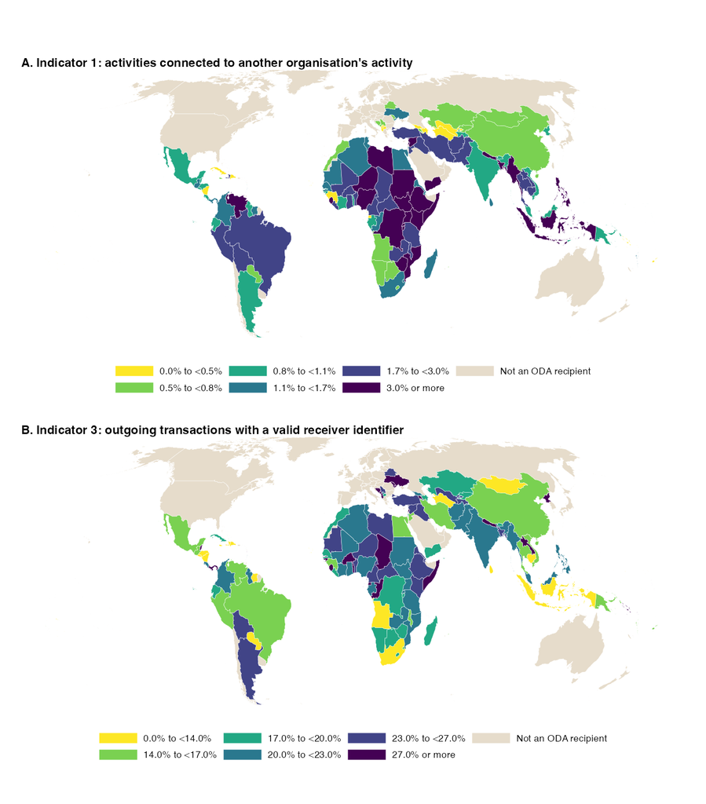

**Figure 15.** Figure 15. Traceability by recipient country, all years: indicators 1 and 3 of Table 4 computed for each recipient country (place level, Section 7.2). A: activities connected to an activity of another organization (indicator 1; unit: activities). B: outgoing commitments and disbursements with a valid receiver identifier (indicator 3; unit: transactions). An activity or transaction that names several countries counts in each (rule ‘every’, Annex A.8). Classes: the boundaries are the sextiles of the ODA recipients with a base of 30 or more across all years (141 countries for indicator 1, 141 for indicator 3), rounded to two significant digits, so each color holds about one sixth of those countries; Countries that are not on the DAC List of ODA Recipients (reporting on 2025 flows, OECD) are drawn in a neutral fill and left out of the classes, so donor countries do not shape the scale. Gray (where present): base below 30, or nothing placed in the country. Tokelau has no shape in the Natural Earth borders and is not drawn. Equal Earth projection.

**2025**

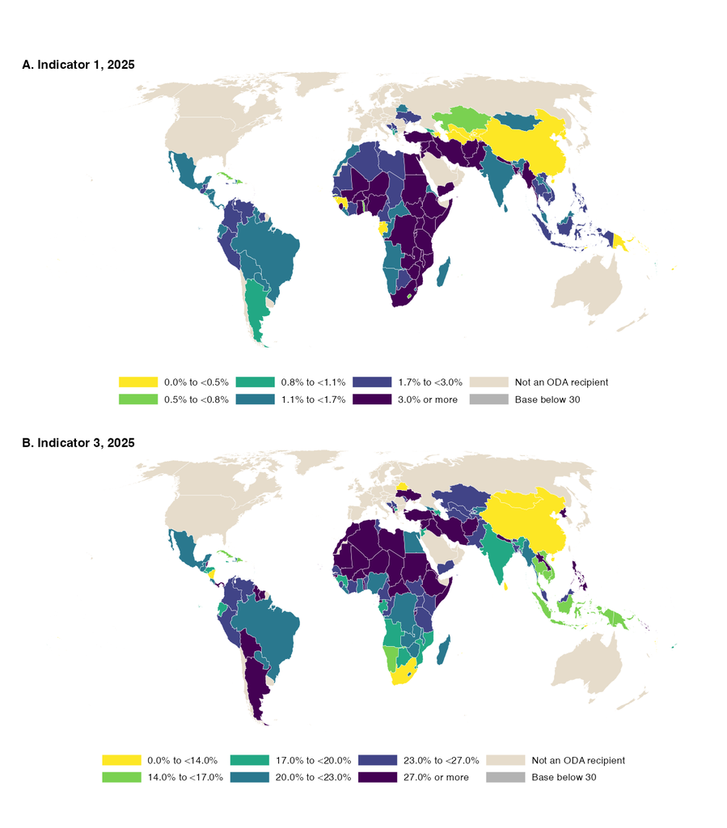

**Figure 15b.** Figure 15b. Traceability by recipient country, transactions dated 2025: indicators 1 and 3 of Table 4 computed for each recipient country (place level, Section 7.2). A: activities connected to an activity of another organization (indicator 1; unit: activities). B: outgoing commitments and disbursements with a valid receiver identifier (indicator 3; unit: transactions). An activity or transaction that names several countries counts in each (rule ‘every’, Annex A.8). Classes: the boundaries are the sextiles of the ODA recipients with a base of 30 or more across all years (141 countries for indicator 1, 141 for indicator 3), rounded to two significant digits, so each color holds about one sixth of those countries; the 2025 maps use the same boundaries as Figure 15, so colors can be compared; Countries that are not on the DAC List of ODA Recipients (reporting on 2025 flows, OECD) are drawn in a neutral fill and left out of the classes, so donor countries do not shape the scale. Gray (where present): base below 30, or nothing placed in the country. Tokelau has no shape in the Natural Earth borders and is not drawn. Equal Earth projection.

**Highest and lowest**

#### Countries with the highest and lowest values of indicators 1 and 3

ODA recipients (DAC list, 2025 flows) with a base of 30 or more; all years; rule ‘every’. Ties at the bottom are ordered by the larger base. Written by report/working_paper.qmd.

#### Indicator 1, highest 20 (unit: activities)

| Rank | Country | Numerator | Denominator | Rate |
| --- | --- | --- | --- | --- |
| 1 | Burundi (BI) | 237 | 4,596 | 5.2% |
| 2 | Democratic Republic of the Congo (CD) | 679 | 13,604 | 5.0% |
| 3 | South Sudan (SS) | 532 | 10,982 | 4.8% |
| 4 | Zimbabwe (ZW) | 404 | 8,737 | 4.6% |
| 5 | Bangladesh (BD) | 531 | 11,915 | 4.5% |
| 6 | Niger (NE) | 295 | 6,680 | 4.4% |
| 7 | Somalia (SO) | 484 | 11,568 | 4.2% |
| 8 | Yemen (YE) | 302 | 7,109 | 4.2% |
| 9 | Kenya (KE) | 878 | 21,531 | 4.1% |
| 10 | Nigeria (NG) | 579 | 14,021 | 4.1% |
| 11 | Sierra Leone (SL) | 246 | 6,067 | 4.1% |
| 12 | Uganda (UG) | 675 | 16,775 | 4.0% |
| 13 | Syrian Arab Republic (SY) | 283 | 7,287 | 3.9% |
| 14 | Ethiopia (ET) | 739 | 19,323 | 3.8% |
| 15 | Lebanon (LB) | 288 | 8,223 | 3.5% |
| 16 | Sudan (SD) | 327 | 9,623 | 3.4% |
| 17 | Nepal (NP) | 326 | 9,550 | 3.4% |
| 18 | Libya (LY) | 76 | 2,320 | 3.3% |
| 19 | Indonesia (ID) | 334 | 10,483 | 3.2% |
| 20 | Rwanda (RW) | 234 | 7,304 | 3.2% |

#### Indicator 1, lowest 20 (unit: activities)

| Rank | Country | Numerator | Denominator | Rate |
| --- | --- | --- | --- | --- |
| 1 | Equatorial Guinea (GQ) | 0 | 678 | 0.0% |
| 2 | Nauru (NR) | 0 | 434 | 0.0% |
| 3 | Saint Helena (SH) | 0 | 194 | 0.0% |
| 4 | Wallis and Futuna (WF) | 0 | 66 | 0.0% |
| 5 | Turkmenistan (TM) | 1 | 1,245 | 0.1% |
| 6 | Samoa (WS) | 3 | 1,282 | 0.2% |
| 7 | Tonga (TO) | 3 | 1,221 | 0.2% |
| 8 | Kosovo (XK) | 15 | 4,523 | 0.3% |
| 9 | Uzbekistan (UZ) | 11 | 3,385 | 0.3% |
| 10 | Fiji (FJ) | 8 | 2,351 | 0.3% |
| 11 | Cabo Verde (CV) | 4 | 1,260 | 0.3% |
| 12 | Tuvalu (TV) | 2 | 681 | 0.3% |
| 13 | Niue (NU) | 1 | 399 | 0.3% |
| 14 | Georgia (GE) | 22 | 6,010 | 0.4% |
| 15 | Nicaragua (NI) | 21 | 4,690 | 0.4% |
| 16 | Albania (AL) | 16 | 4,043 | 0.4% |
| 17 | Guinea (GN) | 17 | 3,988 | 0.4% |
| 18 | Dominican Republic (DO) | 15 | 3,558 | 0.4% |
| 19 | North Macedonia (MK) | 15 | 3,452 | 0.4% |
| 20 | Azerbaijan (AZ) | 11 | 2,475 | 0.4% |

#### Indicator 3, highest 20 (unit: transactions)

| Rank | Country | Numerator | Denominator | Rate |
| --- | --- | --- | --- | --- |
| 1 | Democratic People’s Republic of Korea (KP) | 984 | 1,973 | 49.9% |
| 2 | Guinea-Bissau (GW) | 3,295 | 8,241 | 40.0% |
| 3 | Belize (BZ) | 2,091 | 5,376 | 38.9% |
| 4 | Congo (CG) | 3,300 | 9,301 | 35.5% |
| 5 | Equatorial Guinea (GQ) | 494 | 1,418 | 34.8% |
| 6 | Montenegro (ME) | 1,698 | 4,923 | 34.5% |
| 7 | Ukraine (UA) | 24,609 | 76,026 | 32.4% |
| 8 | Solomon Islands (SB) | 3,458 | 10,841 | 31.9% |
| 9 | Sierra Leone (SL) | 11,651 | 37,473 | 31.1% |
| 10 | Albania (AL) | 5,110 | 16,723 | 30.6% |
| 11 | Lao People’s Democratic Republic (LA) | 8,265 | 27,268 | 30.3% |
| 12 | Togo (TG) | 5,041 | 16,717 | 30.2% |
| 13 | Armenia (AM) | 7,085 | 23,586 | 30.0% |
| 14 | Chad (TD) | 6,891 | 22,989 | 30.0% |
| 15 | Kiribati (KI) | 1,723 | 5,818 | 29.6% |
| 16 | Nepal (NP) | 19,978 | 70,078 | 28.5% |
| 17 | Dominica (DM) | 464 | 1,640 | 28.3% |
| 18 | Burkina Faso (BF) | 16,504 | 58,601 | 28.2% |
| 19 | Moldova (MD) | 6,832 | 24,261 | 28.2% |
| 20 | Nauru (NR) | 644 | 2,297 | 28.0% |

#### Indicator 3, lowest 20 (unit: transactions)

| Rank | Country | Numerator | Denominator | Rate |
| --- | --- | --- | --- | --- |
| 1 | Niue (NU) | 13 | 1,845 | 0.7% |
| 2 | Tokelau (TK) | 6 | 853 | 0.7% |
| 3 | Wallis and Futuna (WF) | 7 | 198 | 3.5% |
| 4 | Timor-Leste (TL) | 1,099 | 21,296 | 5.2% |
| 5 | Micronesia (FM) | 439 | 6,277 | 7.0% |
| 6 | Dominican Republic (DO) | 2,229 | 24,294 | 9.2% |
| 7 | Marshall Islands (MH) | 462 | 5,017 | 9.2% |
| 8 | South Africa (ZA) | 5,961 | 62,779 | 9.5% |
| 9 | Samoa (WS) | 560 | 5,471 | 10.2% |
| 10 | Mongolia (MN) | 2,272 | 21,851 | 10.4% |
| 11 | Tonga (TO) | 681 | 6,546 | 10.4% |
| 12 | Suriname (SR) | 478 | 4,414 | 10.8% |
| 13 | Paraguay (PY) | 1,553 | 13,283 | 11.7% |
| 14 | Tuvalu (TV) | 471 | 4,035 | 11.7% |
| 15 | Indonesia (ID) | 10,084 | 82,997 | 12.1% |
| 16 | Sri Lanka (LK) | 4,651 | 37,574 | 12.4% |
| 17 | Jamaica (JM) | 2,166 | 17,419 | 12.4% |
| 18 | El Salvador (SV) | 3,402 | 27,304 | 12.5% |
| 19 | Angola (AO) | 2,463 | 19,060 | 12.9% |
| 20 | Turkmenistan (TM) | 503 | 3,863 | 13.0% |

**Share and base**

Each point is a country with 30 or more activities (indicator 1) or transactions (indicator 3). Shares on small bases vary more, so the countries at the extremes are often small.

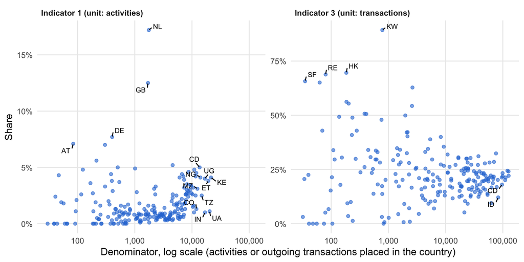

**Interactive**

Hover over a country for numerator / denominator (share) under each multi-country rule. Colors are those of the static maps; zoom with the mouse.

[interactive chart not shown]

**Multi-country rule**

Each point is a country with 30 or more activities or transactions under every rule. Points on the diagonal are not affected by the choice. Under “every”, an activity naming several countries counts in full in each. Under “split”, it is divided by its published percentages.

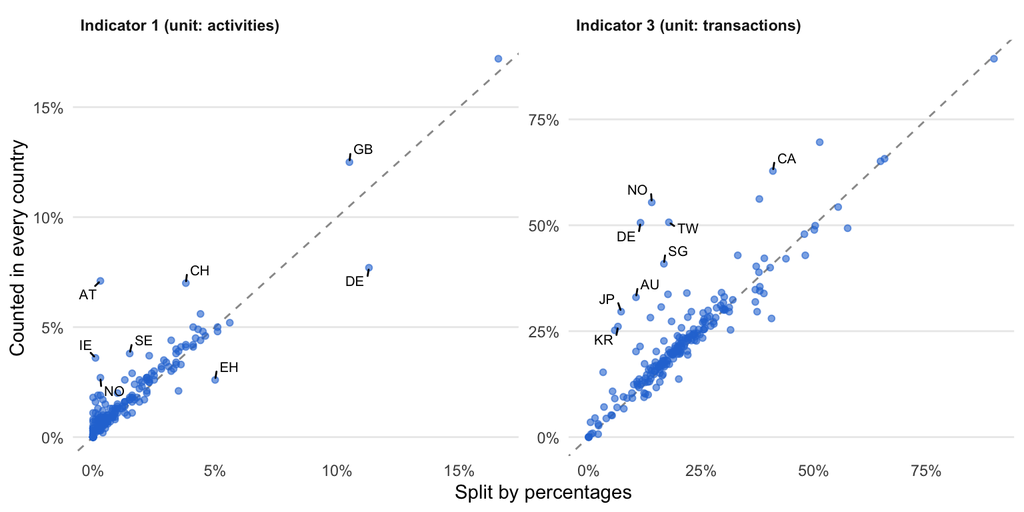

Effect of the multi-country rule, all years.

| indicator | unit | rule | countries | base 30+ | median share, base 30+ (%) |
| --- | --- | --- | --- | --- | --- |
| 1 | activities | every | 252 | 208 | 1.05 |
| 1 | activities | single | 237 | 200 | 0.60 |
| 1 | activities | split | 252 | 201 | 0.60 |
| 3 | transactions | every | 245 | 216 | 21.10 |
| 3 | transactions | single | 236 | 209 | 19.00 |
| 3 | transactions | split | 245 | 210 | 19.20 |

**Not on the map**

Network links by where their end activities can be placed (unit: links).

| side | one country | several countries | region only | no country or region |
| --- | --- | --- | --- | --- |
| funder | 4,458 | 1,748 | 6,311 | 507 |
| receiver | 10,618 | 763 | 1,577 | 66 |

Country codes with no border on the map (24 codes, 1,437 activities in total): AN, BQ, DR, GF, GI, GP, GZ, JD, KO, LE, MQ, RD, RE, SF, SJ, TK, TP, UK, UM, XX, YT, YU, ZR, ZZ. Most are outdated or mistyped codes (for example `UK`, `ZR`, `YU`). The rest are territories that the map draws as part of another country (for example `RE`, `GF`), or placeholders (`XX`, `ZZ`).

### Method: how activities and transactions are placed in countries

The country maps need each activity and each transaction to be given one or more countries. This is done in stage 6 (`06_spatial.py`) in three steps.

**Step 1: which countries.** IATI gives recipient countries at two levels: on the activity (`<recipient-country>` in `<iati-activity>`) and, less often, on single transactions. The rule is:

- An **activity** is placed in the countries it names itself. If it names none, it is placed in all the countries named on its transactions in the scope. Of the 894,287 activities, 466,890 are placed by their own countries, 211,668 by their transactions’ countries only, and 215,729 cannot be placed (including activities with no transactions).
- A **transaction** is placed in its activity’s countries. Only if the activity names none is the transaction’s own country used. The two rarely conflict: 130 of the 7,938 transactions that give a country inside an activity that also gives one name a country that their activity does not list (unit: transactions; in 25 activities).

This is the same rule that stage 5 uses for its country subsets (`common.transaction_countries()`). A country’s indicator 1 and 3 values under the rule “every” are therefore identical to the stage 5 values for that country (checked for Uganda 2025).

**Step 2: which codes are countries.** Only two-letter codes are placed on the map. The country field sometimes holds other codes, such as `GLOBAL`, region numbers (`998`) or three-letter codes (`HTI`). These are left out of the country lists and counted in the tab “Not on the map”. Activities that give only a region, such as `298` “Africa, regional”, are also listed there and not drawn.

**Step 3: activities and transactions that name several countries.** 14,523 activities name two or more countries; 14,396 of them give a percentage for each country. Such an activity cannot be put in one country without a rule. Stage 6 computes the indicators under three rules. The maps show the rule set in `config.MULTI_COUNTRY_RULE` (now “every”); the tab “Multi-country rule” compares all three.

[output not shown]

**A worked example.** The activity below names three countries with percentages. It is connected (it receives funds from a Danida activity through a network link), so it counts in the numerator and the denominator of indicator 1.

```
**Danish Family Planning Association**, *Strategic Partnership 2018-2021* (`DK-CVR-58185728-XM-DAC-3-1-271181-32556`): KE 46%, UG 34%, ET 20%.



Table: What this one activity adds to each country's indicator 1 numerator and denominator (unit: activities), under each rule.

|Country |Published percentage | every| single|split |
|:-------|:--------------------|-----:|------:|:-----|
|KE      |46%                  |     1|      0|0.46  |
|UG      |34%                  |     1|      0|0.34  |
|ET      |20%                  |     1|      0|0.20  |
```

A transaction is treated in the same way, with its activity’s countries and percentages. A commitment of this activity would count as one transaction in each of Kenya, Uganda and Ethiopia under “every”; it would be left out under “single”; and it would count as 0.46, 0.34 and 0.20 of a transaction under “split”.

**What the choice changes.** For most partner countries the three rules give similar shares. Uganda’s indicator 1 is 4.0% under “every”, 3.2% under “single” and 3.4% under “split”. Across countries with 30 or more activities, the median of indicator 1 is 1.1% under “every”, against 0.6% under “single” and 0.6% under “split”. The median of indicator 3 is 21.1%, 19.0% and 19.2%. The rules differ most for donor countries that are listed, often with a small percentage, in large multi-country activities. Under “every” these activities count in full in the donor country.

**Why “every” is used for now.** It matches stage 5’s country subsets, it keeps the counts as whole numbers, and it does not depend on percentages that publishers often omit or fill in loosely. Its drawback is that a multi-country programme carries the same weight in a country it barely touches as in its main country. “Split” corrects this, but it depends on the published percentages. The choice is open (`docs/methods_decisions.md`, section 7).

**Small bases.** A country is gray (“Base below 30”) when fewer than 30 activities (indicator 1) or transactions (indicator 3) are placed in it under the rule shown. A share on such a base can change by several points with one activity. Under “split”, the base is the sum of the shares, so it can be a fraction. The column `records` in `country_indicators.csv` gives the number of activities or transactions behind each denominator, each counted once.

## 10. Funding that reaches mapped local work

Section 9 shows traceability by country. This section goes below country level. It shows chains of funding that can be followed, activity by activity, from a funder through intermediaries to an implementing organization, and that end at an activity which publishes where it works. These are rare, so the section presents **examples**, not a measure. The aim is to show what full traceability looks like when it reaches smaller, local organizations, and what is lost when it does not.

- **Locations.** 649,578 locations are published for 255,297 activities (unit: locations; activities). 195,195 activities give at least one valid point; 178,567 give at least one usable point (inside a recipient country, below country level).
- **In the network.** 2,954 of the 14,716 activities in the network have a valid point (unit: activities).
- **Chains.** Of 1,771 chains of two or more steps, 176 end at an activity with a usable point, and 17 of these end at a local organization (unit: chains). 1,434 end at an activity with no location at all.

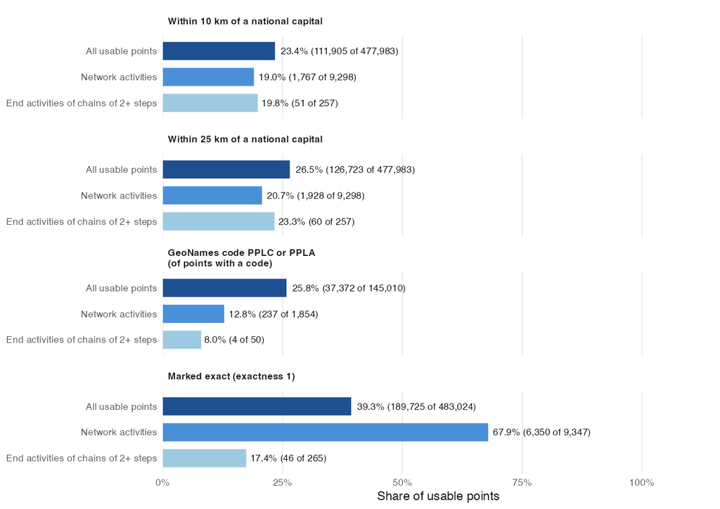

**Figure 19.** Are published locations at capital cities? Usable points (Section 7.4: a valid coordinate inside a recipient country and not coded as the whole country; not one of the Table 4 indicators). Distance: to the nearest national capital of the activity’s recipient countries (Natural Earth 1:50m populated places; countries with several capitals keep all; 5,041 points in countries without a listed capital are left out of the distance measures). GeoNames codes: PPLC, capital of a political entity; PPLA, seat of a first-order administrative division, among the points that publish a code (30.0% of usable points). Exactness: 1 exact, 2 approximate. Network activities: activities in the activity network; chain ends: end activities of chains of 2 or more steps. Labels: share (points meeting the condition of the base). All years. Unit: location points. By publisher type: figures/wp/location_precision.csv.

**Ethiopia**

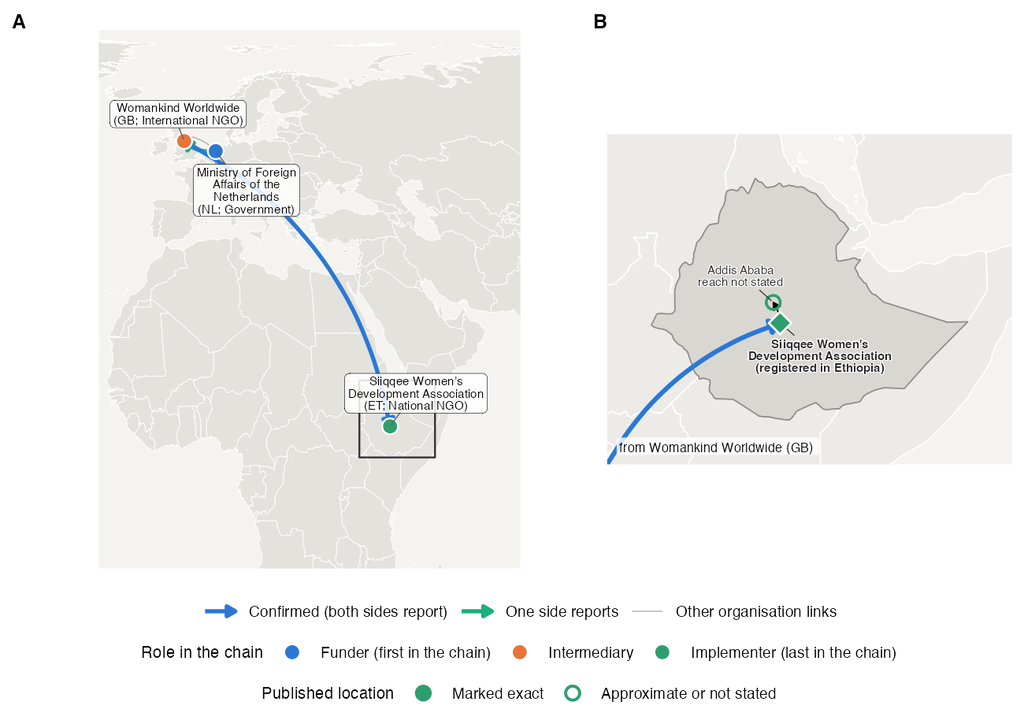

**Figure 20.** Figure 20. A chain from Ministry of Foreign Affairs of the Netherlands to Siiqqee Women’s Development Association, 2 steps (1 confirmed by both sides), years 2021 to 2026. Relates to the place level of Table 4 (Section 7.4) and the chain level (Section 6). A: organizations placed by country of registration, each labeled with its full name, country of registration and IATI organization type; color shows the organization’s role, taken from its position in the chain (first: funder; last: implementer; between: intermediary), not from an IATI field. Arrows: the chain’s activity links, colored by evidence as in the chain diagrams (blue: confirmed by both sides; green: reported by one side); gray: other organization links of the same organizations (up to 15 each). Box: the end country. B: the end country (equal-area projection centred on it); the implementer (diamond) is drawn at the country’s label point, not at a published location, with arrows to the usable points its end activity publishes (1), each labeled with its published name and location reach (activity site, or where beneficiaries live); filled if marked exact, hollow if approximate or not stated. Equal Earth projection (A). Unit: organizations; activity links; location points.

**Nepal**

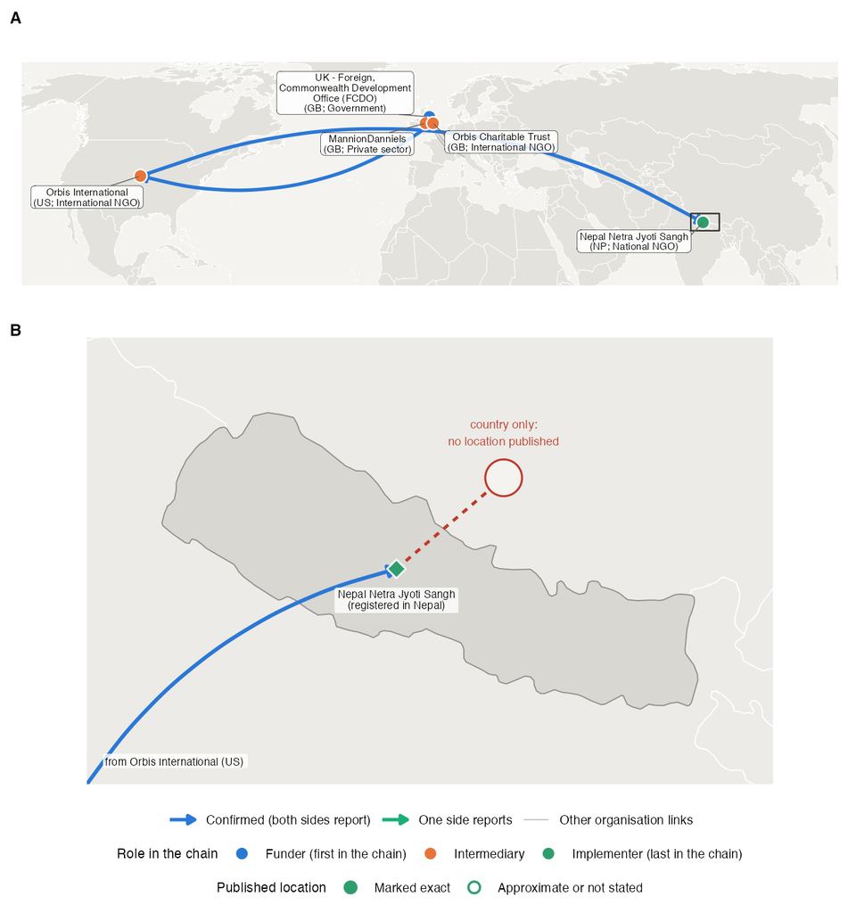

**Figure 21.** Figure 21. A chain from UK - Foreign, Commonwealth Development Office (FCDO) to Nepal Netra Jyoti Sangh, 4 steps (3 confirmed by both sides), years 2018 to 2023. Relates to the place level of Table 4 (Section 7.4) and the chain level (Section 6). A: organizations placed by country of registration, each labeled with its full name, country of registration and IATI organization type; color shows the organization’s role, taken from its position in the chain (first: funder; last: implementer; between: intermediary), not from an IATI field. Arrows: the chain’s activity links, colored by evidence as in the chain diagrams (blue: confirmed by both sides; green: reported by one side); gray: other organization links of the same organizations (up to 15 each). Box: the end country. B: the end country (equal-area projection centred on it); the implementer (diamond) is drawn at the country’s label point, not at a published location, with arrows to the usable points its end activity publishes (0), each labeled with its published name and location reach (activity site, or where beneficiaries live); filled if marked exact, hollow if approximate or not stated. This end activity publishes no usable location (no location); the dashed line marks the missing location. Equal Earth projection (A). Unit: organizations; activity links; location points. Panel A is cropped to the chain’s organizations (United Kingdom, United States, Nepal), so it spans a wide, shallow area and is drawn above panel B.

**Other example chains**

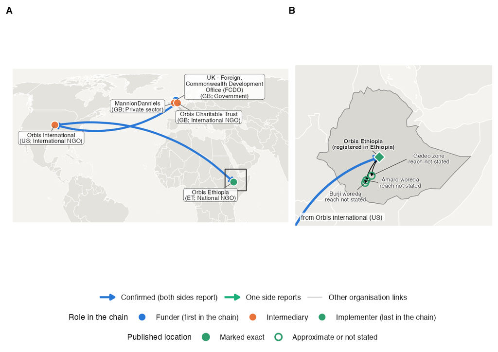

**Figure 23.** Example chain map (showcase rank 1 of 5; selection rule in Annex A.8). A chain from UK - Foreign, Commonwealth Development Office (FCDO) to Orbis Ethiopia, 4 steps (3 confirmed by both sides), years 2016 to 2023. Relates to the place level of Table 4 (Section 7.4) and the chain level (Section 6). A: organizations placed by country of registration, each labeled with its full name, country of registration and IATI organization type; color shows the organization’s role, taken from its position in the chain (first: funder; last: implementer; between: intermediary), not from an IATI field. Arrows: the chain’s activity links, colored by evidence as in the chain diagrams (blue: confirmed by both sides; green: reported by one side); gray: other organization links of the same organizations (up to 15 each). Box: the end country. B: the end country (equal-area projection centred on it); the implementer (diamond) is drawn at the country’s label point, not at a published location, with arrows to the usable points its end activity publishes (3), each labeled with its published name and location reach (activity site, or where beneficiaries live); filled if marked exact, hollow if approximate or not stated. Equal Earth projection (A). Unit: organizations; activity links; location points.

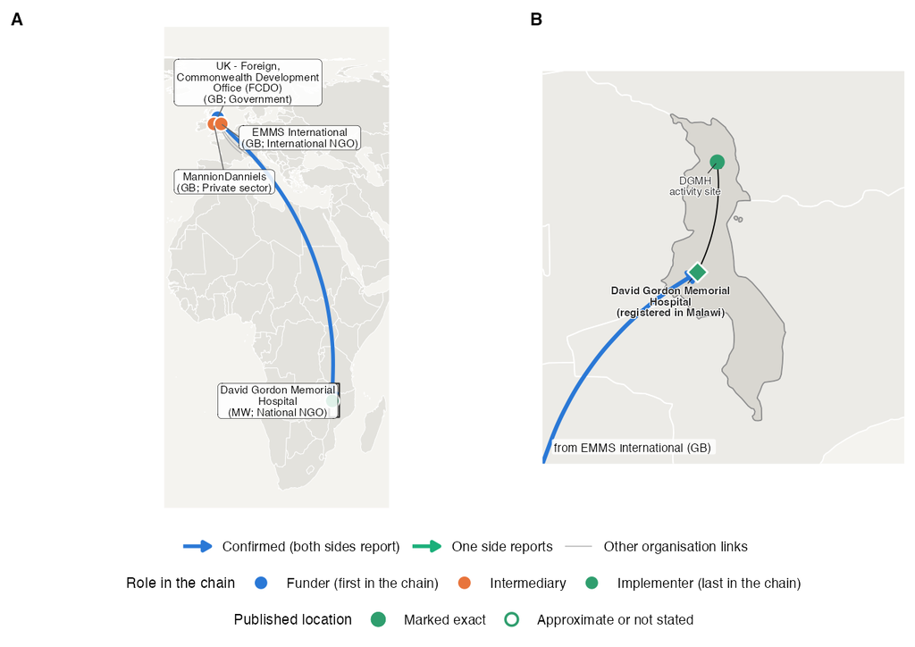

**Figure 24.** Example chain map (showcase rank 2 of 5; selection rule in Annex A.8). A chain from UK - Foreign, Commonwealth Development Office (FCDO) to David Gordon Memorial Hospital, 3 steps (2 confirmed by both sides), years 2018 to 2022. Relates to the place level of Table 4 (Section 7.4) and the chain level (Section 6). A: organizations placed by country of registration, each labeled with its full name, country of registration and IATI organization type; color shows the organization’s role, taken from its position in the chain (first: funder; last: implementer; between: intermediary), not from an IATI field. Arrows: the chain’s activity links, colored by evidence as in the chain diagrams (blue: confirmed by both sides; green: reported by one side); gray: other organization links of the same organizations (up to 15 each). Box: the end country. B: the end country (equal-area projection centred on it); the implementer (diamond) is drawn at the country’s label point, not at a published location, with arrows to the usable points its end activity publishes (1), each labeled with its published name and location reach (activity site, or where beneficiaries live); filled if marked exact, hollow if approximate or not stated. Equal Earth projection (A). Unit: organizations; activity links; location points.